# How Racial Capitalism Persits today in Lexington, KY

## An exploration of 1930s Redlining Practices

This notebook covers the steps taken to collect and pre-process data for redlining-wealth-health-lexington github repo.

- Dependencies
- Intro to US Census Bureau Data
- Intro to Lexington's Data Portal
- Data Used
- Inspiration for Maps
- End of Day Thoughts
- Exploring Data Sets
  - Race/Segregation Data
    - Drop a Feature/Column
    - Rename Columns & Remove Row Identifier
  - Census Bureau Tract Data 2019
  - Merge Race/Segregation Data & Census Bureau Tract Data
    - Map Race/Segregation Data
      - Clipping to New Circle
      - Clip by HOLC neighborhoods
  - Median Household Income
    - Drop Attributes/Columns
    - Rename Columns & Remove Row Identifier
  - Merge Houshold Income with Race/Segregation/Census Bureau Tracts GDF
  - Calculate Percent White vs Black & Add to geopandas df
  - Home Ownership/Property Value Data
    - Rename Columns & Remove Row Identifier
  - Merge Ownership & Prop Value with HHI/Race/Segregation/CB Tracts GDF
  - Refine Merged File

## Dependencies

Required environment dependencies (actually loaded into environment):  
**jupyter notebook** conda install -c conda-forge jupyter  
**numpy** conda install -c conda-forge numpy  
**geopandas** conda install --channel conda-forge geopandas  
**pandas** (version 0.24 or later) conda install -c conda-forge pandas  
**shapely** (interface to GEOS) conda install -c conda-forge shapely  
**fiona** (interface to GDAL) conda install -c conda-forge fiona  
**matplotlib** (>=2.2.0) conda install -c conda-forge matplotlib  
**pyproj** (interface to PROJ; version 2.2.0 or later) conda install -c conda-forge pyproj

Further, optional dependencies (actually loaded into environment:  
**rtree** (optional; spatial index to improve performance and required for overlay operations; interface to libspatialindex) conda install -c conda-forge rtree  
**psycopg2**(optional; for PostGIS connection) conda install -c conda-forge psycopg2  
**GeoAlchemy2** (optional; for writing to PostGIS)conda install -c conda-forge geoalchemy2  
**geopy** (optional; for geocoding) conda install -c conda-forge geopy

For plotting, these additional packages may be used:  
**mapclassify**(>=2.2.0)

## Intro to US Census Bureau Data

[Video](https://www.youtube.com/watch?v=1LZPYS0cR68) detailing how to access data for specific census tracts.  
Can find US Census data [here](https://mtgis-portal.geo.census.gov/arcgis/apps/MapSeries/index.html?appid=2566121a73de463995ed2b2fd7ff6eb7) on the 2020 Census Bureau Demographic Data Map Viewer OR here

#### Data Hierarchy

Data within the US Census bureau is organized in a hierarchy of: Nation-> State -> County -> Tract -> Block Group -> Block Where a Nation is composed of many states which are composed of many counties etc..

Will need to use these sites to determine the exact census tracts for data interested in. Will most likely need use the tract name to merge or join tables.

[Census tracts and tract codes](https://transition.fcc.gov/form477/Geo/more_about_census_tracts.pdf) [GEOIDS Specifics](https://www.census.gov/programs-surveys/geography/guidance/geo-identifiers.html)

- The decimal point separating the 4-digit basic tract code from the 2-digit suffix is shown in US Census Bureau printed reports and maps. However, in computer-readable files prepared by the Census Bureau decimal point is implied and does not appear.
- A census tract code may not be used more than once in a single county, but it may be used again in a different county in the same state or in a county in a different state. Therefore must be identified by: its state, its county, and its tract code.
- 11-digit code consisting of
  - 2 digits for state (FIPS code)
  - 3 digits for county (FIPS code)
  - 6 digits for census tract
  - All may have one or more leading 0's and two trailing 0's

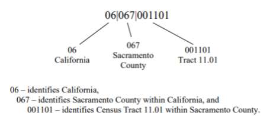

#### Where to find data

If using **data.census.gov**  
From here site click *advanced search* and select what filters to work through.  
This section of the site is great for a gui that allows you to quickly visualize data attribute tables and polygons on a map.

Geography example:  
Click advanced search-geography filter-select the hierarchy level wish to pull-state-county-within (tract)  
To only pull data from 2020 census click on year filter and select year of interest  
To only pull data from specific census click on surveys filter and select survey of interest  
Click search (data tables resulting from these filters will populate)  
Can then either download the table in csv or look in map format

For example I chose  
advanced search-geography-block-kentucky-fayette-all blocks within fayette county

Another option (great for knowing specific topic of interest but not the name of the precise survey needed to view in gui from above site.) use **census.gov/data.html**  
From here click browse by topic, search in search bar with simple terms to find correct abbreviation of interest then return to data.census.gov and search for abbreviation of interest (example: DP04 or S1901) and refine as described above.

#### Promising Surveys

**DP4 Profile of Selected Housing Characteristics: 2000** Decennial Survey (since this is older data will try to utilize DP04 instead).  
**DP04 Selected Housing Characteristics (2019: ACS American Community Survey 5 year estimates data profiles**  
Housing units, Structure type, year built, number of rooms, year householder moved into unit (establish long term owners), vehicles, house heating, *specified owner occupying units value vs renter units*, *value owner-occupied units*, *gross rent*, *gross rent as % of household income*  
**DP02 Selected Social Characteristics in the United States (2019: ACS 5-Year Estimates Data Profiles**  
Educational attainment, Disability status, residence length, with a computer, with broadband internet **S1701 Poverty Status in the past 12 months (ACS)**  
Estimate of total number of people for whom poverty status was determined (poverty or not) with below poverty level numbers calculated per census tract.  
**S1901 Income in the past 12 months (in 2019 inflation-adjusted dollars)**  
Household income range, Median income

## Intro to Lexington's Data Portal

Data from this portal was not used in the final project. It is saved within this notebook as an option to return to for future data comparisons.

Lexington has some data already configured in their own archub data portal gui to demo files from some census tract work and past work provided by other private uploaders to the site. Some potential data sets of interest to begin with are below. If I persue further information regaring health or access to certain spaces I may return to this data. Currently looking to pull most data from Census Bureau. https://data-lfucg.hub.arcgis.com/

**GOOD DATA FILE for neighborhoods but no common ground to merge.** Census 2020 by Race for 18 and Over by Preceinct in geoJSON format accessed 1/27/2022 from [here](https://data-lfucg.hub.arcgis.com/datasets/a1e93b1a225a4bb79baa00190e2b212c_0/explore?location=38.029745%2C-84.464568%2C13.69)

This is an alternative option to finding census tracts as they should be included in this geojson from 2020 census. This data set containes the names of the neighborhoods. This data set also uses a unique change in identification. In 2020 there was an option to identify as more than one race (multiracial). Will need to consider this when exploring the race make up of the precincts. Can use the dominate identifiers or be more specific i.e. white alone vs black or african american alone vs *race 1 and race 2*

Would like to know what CODE stands for, example CODE C129 and NAME IDLE HOUR. is C129 part of a precinct number?

[**GOOD DATA FILE for Census Tracts 2010**](https://data-lfucg.hub.arcgis.com/datasets/6cb9e8be350d45d19f1e517d2e9c4e4b_0/explore?location=38.041424%2C-84.451398%2C12.05) Good example of tract number identification from 2010 census tracts. It would appear **NAME10** on Census Tract 2010 corresponds to **BASENAME** for Census Tract in US Census Bureau 2019 census. Caveat in using this data is it's dated. Should find more up to date data file.

[**GOOD DATA FILE for Census Tracts & Race**](https://data-lfucg.hub.arcgis.com/datasets/8c1d1363e6ce4822b818a51469f4f502_0/explore) Census 2020 Precinct_p1_race

[**GOOD DATA FILE for Landuse (Vacancies)**](https://data-lfucg.hub.arcgis.com/datasets/8113df2403c048a0837a0bec68906f3a_0/explore?filters=eyJMVTIwMDUiOlsiU0YiLCJNRiIsIkQiLCJDT00iLCJWQUMiXX0%3D&location=38.031300%2C-84.466517%2C13.19) Only issue is that the landuse may be from 2005.

[**Good DATA FILE for Parks**](https://data-lfucg.hub.arcgis.com/datasets/764044274e974dbba9069d9dab7dcb34_0/explore?location=38.037063%2C-84.482212%2C13.06) Park type, acreage. Need to check and see if this is more up to date than the previous park project completed in lex_redlined_and_parks personal repo

[**Property values Option B**](https://qpublic.schneidercorp.com/Application.aspx?AppID=1019&LayerID=21445&PageTypeID=4&PageID=9143&Q=1076636217&KeyValue=40100350) allowed 100 free look ups first month each additional month 50 free look ups. could limit the look ups to one holc a and one holc d?

[**Occupancy Status by Precinct Census 2020**](https://data-lfucg.hub.arcgis.com/datasets/4ce0a61b95764366a1971f5960a10690_0/explore?location=38.028065%2C-84.471929%2C13.69) Occupied vs vacant reported properties

[**Greenway**](https://data-lfucg.hub.arcgis.com/datasets/79605c14aebf4bbb98c6df79c6e539ec_0/explore?location=38.022719%2C-84.458785%2C16.91) acreage of greenspace

[**Railway**](https://data-lfucg.hub.arcgis.com/datasets/7671e2d17391430ebca3e88e547a0cb0_0/explore?location=38.056548%2C-84.478677%2C13.08) line work for railways in lex

Impervious Area 2007 (private upload can download as shapefile) Tree Canopy (private upload can download as shapefile)

Other data sets of interest for another day: Various school zones (districts?) Library Bicycle Network

## Data Used

It does appear the US Census Bureau will be releasing their 2020 data come Mid March. Possible idea would be to revisit this project with updated data come April.

#### Links to Data

- Census Bureau Census Tract
  - [2019 Shapefile](https://www.census.gov/geographies/mapping-files/time-series/geo/cartographic-boundary.2019.html)
    - Shapefile
    - 2.27 MB
    - Accessed 13 February 2022
    - [Glossary](https://www2.census.gov/geo/tiger/GENZ2019/2019_file_name_def.pdf?#)
  - [2020 Shapefile](https://www.census.gov/geographies/mapping-files/time-series/geo/cartographic-boundary.html) If end up coming back for 2020 data
- HOLC Graded Neighborhood Polygons
  - [Mapping Inequality Redlining in New Deal America](https://dsl.richmond.edu/panorama/redlining/#loc=14/38.041/-84.526&city=lexington-ky&text=downloads)
    - Shapefile or GeoJSON
    - Georectified Image
    - Scan jpg
    - Citation: Robert K. Nelson, LaDale Winling, Richard Marciano, Nathan Connolly, et al., “Mapping Inequality,” American Panorama, ed. Robert K. Nelson and Edward L. Ayers, accessed February 2, 2022, https://dsl.richmond.edu/panorama/redlining/#loc=14/38.041/-84.526&city=lexington-ky&text=downloads.
- Race/Segregation
  - [*Race for the Population 18 years+ 2020*](https://data.census.gov/cedsci/table?q=p3&t=Race%20and%20Ethnicity&g=0500000US21067%241400000&y=2020)
  - Data available to download in:
    - CSV metadata
    - CSV file data
    - TXT file table title
    - Accessed: 8 Feb 2022
    - Citation:
    - Notes: Census Data utilized was for those identifying as a Population of one race. Options to declare included White alone, Black or African American alone, American Indian and Alaska Native alone, Asian alone, Native Hawaiian and Other Pacific Islander Alone, Some Other Race alone (literally a category). Additional options existed to self declare population of 2 or more races. Only selected data for populations identifying as a single race either White alone OR Black or African American alone. This was selected as identifying as a single race identified as white or Black was the purpose of exploration in relation to HOLC 1930s neighborhood identifications. Will need to revisit this to determine if need to summarize all races that do not identify as White Alone to give voice and speak to races that White Alone during the HOLC neighborhood error would have identified as minority.
- Median Household income
  - [*S1901 Income in the past 12 months (in 2019 inflation-adjusted dollars)*](https://data.census.gov/cedsci/table?q=income&g=0500000US21067%241400000&y=2019)
  - This data was based on 2019 ACS 5-Year Estimates
  - CSV file type includes:
    - CSV file metadata
    - CSV file data
    - TXT file table title
    - 19.4 kb if full Fayette County
    - 7.5 kBb if only pulling census tracts that overlap/intersect with HOLC neighborhoods
    - Accessed: 2 March 2022
    - Citation:
- Mortgage approval rates through time (HMDA home mortgage disclosure act data, by census tract number, race of applicant, not sure if approvals/denials within large data set too large to open in excel)
  - ?????????
- Census Tracts for mapping!!!!
  - ?????????
- Percent homeownership today
  - [*US census bureau American Community Survey DP04 2019*](https://data.census.gov/cedsci/table?q=DP04&g=0500000US21067%241400000)
  - CSV File type includes:
    - CSV file metadata
    - CSV file data
    - TXT file table title
    - 88.5 kb if full fayette county
    - if only pulling census tracts that overlap/intersect with HOLC neighborhoods
    - Accessed: 2 March 2022
    - Citation:
- Property values today
  - [*US census bureau American Community Survey DP04 2019*](https://data.census.gov/cedsci/table?q=DP04&g=0500000US21067%241400000) has owner reported value of house in range
  - CSV File type includes:
    - CSV file metadate
    - CSV file data
    - TXT file table title
    - 88.5 kb if full Fayette County (already pulling for Percent Homeownership today)
    - if only pulling census tracts that overlap/intersect with HOLC neighborhoods
    - Accessed: 2 March 2022
    - Citation:
- % of population in poverty
  - [*S1701 Poverty Status in the past 12 months (ACS)*](https://data.census.gov/cedsci/table?q=s1701&g=0500000US21067%241400000&y=2019)
  - [Symbols](https://www.census.gov/data/tables/time-series/demo/income-poverty/cps-pov/pov-01.2019.html#par_textimage_9999998) used in tables:
    - (B) Base less than 75,000
    - (X) Estimate is not applicabple or not available
    - (Z) Rounds to zero
  - CSV File type includes:
    - CSV File Metadata
    - CSV file data
    - TXT file table title
    - 59.7 kb
    - Accessed:
    - Citation:
- Quality of property
  - NLCD Tree Land Cover data set? or tree coverage from lex
  - impervious surface coverage from LEX
  - distance to park (ref previous project)
  - vacant lots nearby
  - nearby railroad
- Timeline (Journal articles to reference history and development of Lexington)
  - May use images from journal articles for demo. Articles of interest:
    - Kellogg, John. 1982. The Formation of Black Residential Areas in Lexington, Kentucky 1865-1887. Southern Historical Association. Vol 48. No 1. pp. 21-52.
    - O'Malley, Nancy. 2002. The Pursuit of Freedom The Evolution of Kinkeadtown, an African American Post-Civil War Neighborhood in Lexington, Kentucky. Winterthur Portfolio. Vol 37. No. 4. pp. 187-218.
    - Rabinowitz, Howard. 1976. From Reconstruction to Redemption in the Urban South. Journal of Urban History. Vol 2. No 2. pp 169-194
    - Kellogg, John. 1977. Negro Urban Clusters in the Posbellum South. Geographical Review. Vol 67. No 3. pp. 310-321.
    - Kendi, Ibram. 2016. Stamped from the Beginning The Definitive History of Racist Ideas in America. New York, Bold Type Books. pp 583.

## Inspiration for Maps

- [ramp styling 2020 census by race](https://mtgis-portal.geo.census.gov/arcgis/apps/MapSeries/index.html?appid=2566121a73de463995ed2b2fd7ff6eb7)
- [overalp of holc designations & secondary ramp map](https://mtgis-portal.geo.census.gov/arcgis/apps/MapSeries/index.html?appid=2566121a73de463995ed2b2fd7ff6eb7)

### End of Day Thoughts:

Items to consider at a later date. *Determine what years data is available for interest, then select correct census tract that best corresponds to these. (It appears the latest data is 2019 with the exception that come Mid March new 2020 census data will be released from US Census Bureau)*Would be interesting to look at impervious surfaces vs tree canopy as a way to analyse simple pleasure of green. look for the demarcation of affluent areas by satellite? or aerial imagery (inspiration Bunge 2011 from map719) green grass on a colored aerial photograph almost perfectly maps the territory of the affluent-their campuses, expressways, downtown business center, parks, and homes. The affluent are surrounded by private parks.

# Exploring Data Sets

```python
# load require packages for exploring spatial data analysis
import pandas as pd
import numpy as np
import matplotlib.pyplot as plt
```

## Race/Segregation Data

Load data

```python
# Load CSV data as pandas DataFrame
race_df = pd.read_csv('./data/race_pop_18up_2020/race_pop_18up_2020.csv')
```

```python
#Verify race_df now references pandas DataFrame object, not CSV file
type(race_df)
```

```
pandas.core.frame.DataFrame
```

First glimpse data

```python
# get an idea for starting place of information
race_df.info()

#83 individual entries
```

```
<class 'pandas.core.frame.DataFrame'>
RangeIndex: 83 entries, 0 to 82
Data columns (total 73 columns):
 #   Column   Non-Null Count  Dtype
---  ------   --------------  -----
 0   GEO_ID   83 non-null     object
 1   NAME     83 non-null     object
 2   P3_001N  83 non-null     object
 3   P3_002N  83 non-null     object
 4   P3_003N  83 non-null     object
 5   P3_004N  83 non-null     object
 6   P3_005N  83 non-null     object
 7   P3_006N  83 non-null     object
 8   P3_007N  83 non-null     object
 9   P3_008N  83 non-null     object
```

[output cut: 65 more lines]

View first 5 rows

```python
# Initial Look at data with first 5 rows
race_df.head(5)
```

|  | GEO_ID | NAME | P3_001N | P3_002N | P3_003N | P3_004N | P3_005N | P3_006N | P3_007N | P3_008N | P3_009N | P3_010N | P3_011N | P3_012N | P3_013N | P3_014N | P3_015N | P3_016N | P3_017N | P3_018N | P3_019N | P3_020N | P3_021N | P3_022N | P3_023N | P3_024N | P3_025N | P3_026N | P3_027N | … |
| --- | --- | --- | --- | --- | --- | --- | --- | --- | --- | --- | --- | --- | --- | --- | --- | --- | --- | --- | --- | --- | --- | --- | --- | --- | --- | --- | --- | --- | --- | --- |
| 0 | id | Geographic Area Name | !!Total: | !!Total:!!Population of one race: | !!Total:!!Population of one race:!!White alone | !!Total:!!Population of one race:!!Black or A... | !!Total:!!Population of one race:!!American I... | !!Total:!!Population of one race:!!Asian alone | !!Total:!!Population of one race:!!Native Haw... | !!Total:!!Population of one race:!!Some Other... | !!Total:!!Population of two or more races: | !!Total:!!Population of two or more races:!!P... | !!Total:!!Population of two or more races:!!P... | !!Total:!!Population of two or more races:!!P... | !!Total:!!Population of two or more races:!!P... | !!Total:!!Population of two or more races:!!P... | !!Total:!!Population of two or more races:!!P... | !!Total:!!Population of two or more races:!!P... | !!Total:!!Population of two or more races:!!P... | !!Total:!!Population of two or more races:!!P... | !!Total:!!Population of two or more races:!!P... | !!Total:!!Population of two or more races:!!P... | !!Total:!!Population of two or more races:!!P... | !!Total:!!Population of two or more races:!!P... | !!Total:!!Population of two or more races:!!P... | !!Total:!!Population of two or more races:!!P... | !!Total:!!Population of two or more races:!!P... | !!Total:!!Population of two or more races:!!P... | !!Total:!!Population of two or more races:!!P... | … |
| 1 | 1400000US21067000101 | Census Tract 1.01, Fayette County, Kentucky | 2781 | 2562 | 1916 | 492 | 17 | 70 | 2 | 65 | 219 | 197 | 32 | 45 | 35 | 0 | 69 | 10 | 2 | 2 | 1 | 0 | 0 | 0 | 0 | 0 | 1 | 21 | 16 | … |
| 2 | 1400000US21067000102 | Census Tract 1.02, Fayette County, Kentucky | 1339 | 1280 | 991 | 262 | 4 | 14 | 0 | 9 | 59 | 58 | 10 | 8 | 14 | 2 | 17 | 5 | 0 | 0 | 0 | 0 | 0 | 0 | 0 | 2 | 0 | 1 | 1 | … |
| 3 | 1400000US21067000200 | Census Tract 2, Fayette County, Kentucky | 2709 | 2594 | 1790 | 708 | 5 | 22 | 2 | 67 | 115 | 114 | 50 | 13 | 17 | 0 | 25 | 1 | 0 | 0 | 5 | 0 | 0 | 0 | 3 | 0 | 0 | 1 | 0 | … |
| 4 | 1400000US21067000300 | Census Tract 3, Fayette County, Kentucky | 2227 | 2058 | 971 | 1004 | 13 | 5 | 0 | 65 | 169 | 144 | 35 | 41 | 12 | 0 | 35 | 5 | 1 | 0 | 10 | 0 | 0 | 4 | 1 | 0 | 0 | 25 | 16 | … |

See all column headers

```python
# Confirm seeing all columns
pd.options.display.max_columns = None
# Initial Look at data
race_df.head(5)
```

|  | GEO_ID | NAME | P3_001N | P3_002N | P3_003N | P3_004N | P3_005N | P3_006N | P3_007N | P3_008N | P3_009N | P3_010N | P3_011N | P3_012N | P3_013N | P3_014N | P3_015N | P3_016N | P3_017N | P3_018N | P3_019N | P3_020N | P3_021N | P3_022N | P3_023N | P3_024N | P3_025N | P3_026N | P3_027N | … |
| --- | --- | --- | --- | --- | --- | --- | --- | --- | --- | --- | --- | --- | --- | --- | --- | --- | --- | --- | --- | --- | --- | --- | --- | --- | --- | --- | --- | --- | --- | --- |
| 0 | id | Geographic Area Name | !!Total: | !!Total:!!Population of one race: | !!Total:!!Population of one race:!!White alone | !!Total:!!Population of one race:!!Black or A... | !!Total:!!Population of one race:!!American I... | !!Total:!!Population of one race:!!Asian alone | !!Total:!!Population of one race:!!Native Haw... | !!Total:!!Population of one race:!!Some Other... | !!Total:!!Population of two or more races: | !!Total:!!Population of two or more races:!!P... | !!Total:!!Population of two or more races:!!P... | !!Total:!!Population of two or more races:!!P... | !!Total:!!Population of two or more races:!!P... | !!Total:!!Population of two or more races:!!P... | !!Total:!!Population of two or more races:!!P... | !!Total:!!Population of two or more races:!!P... | !!Total:!!Population of two or more races:!!P... | !!Total:!!Population of two or more races:!!P... | !!Total:!!Population of two or more races:!!P... | !!Total:!!Population of two or more races:!!P... | !!Total:!!Population of two or more races:!!P... | !!Total:!!Population of two or more races:!!P... | !!Total:!!Population of two or more races:!!P... | !!Total:!!Population of two or more races:!!P... | !!Total:!!Population of two or more races:!!P... | !!Total:!!Population of two or more races:!!P... | !!Total:!!Population of two or more races:!!P... | … |
| 1 | 1400000US21067000101 | Census Tract 1.01, Fayette County, Kentucky | 2781 | 2562 | 1916 | 492 | 17 | 70 | 2 | 65 | 219 | 197 | 32 | 45 | 35 | 0 | 69 | 10 | 2 | 2 | 1 | 0 | 0 | 0 | 0 | 0 | 1 | 21 | 16 | … |
| 2 | 1400000US21067000102 | Census Tract 1.02, Fayette County, Kentucky | 1339 | 1280 | 991 | 262 | 4 | 14 | 0 | 9 | 59 | 58 | 10 | 8 | 14 | 2 | 17 | 5 | 0 | 0 | 0 | 0 | 0 | 0 | 0 | 2 | 0 | 1 | 1 | … |
| 3 | 1400000US21067000200 | Census Tract 2, Fayette County, Kentucky | 2709 | 2594 | 1790 | 708 | 5 | 22 | 2 | 67 | 115 | 114 | 50 | 13 | 17 | 0 | 25 | 1 | 0 | 0 | 5 | 0 | 0 | 0 | 3 | 0 | 0 | 1 | 0 | … |
| 4 | 1400000US21067000300 | Census Tract 3, Fayette County, Kentucky | 2227 | 2058 | 971 | 1004 | 13 | 5 | 0 | 65 | 169 | 144 | 35 | 41 | 12 | 0 | 35 | 5 | 1 | 0 | 10 | 0 | 0 | 4 | 1 | 0 | 0 | 25 | 16 | … |

In first glance we won't need all of the columns within the dataframe.

- Glossary for header codes can be found in metadata.csv file ('./data/race_pop_18up_2020/race_pop_18up_2020_metadata.csv')
- Need to reduce to only those columns of interest.
  - Keep the following (and rename):
    - Total = **P3_001N**
    - Total: Population of one Race: White alone = **P3_003N**
    - Total: Population of one Race: Black or African American alone = **P3_004N**
  - Drop the following:
    - **P3_002N, P3_005N:P3_071N**
- Will also need to include a note in analysis that all other races were not considered as this was an exploration only of the White and Black populations (represented as a single race). This is not in an effort to exclude or hide other races. This project is meant as an exploration of how the practice of Redlining was geared toward (at the time 1930) the racial identity of the neighborhoods that were typically either dominated by primarily white or black populations.
- If this doesn't sit right can always do another version of the data set where include white alone vs populations identifying as any other race besides white.
- Need to reduce to only census tracts of interest, though this may be easier accomplished once mapped to know which to keep.

### Drop a Feature/Column

Drop attributes/columns that are unnecesssary to reduce size and make more legible.

```python
# To Drop Columns
to_drop1 = ['P3_002N', 'P3_005N', 'P3_006N','P3_007N','P3_008N','P3_009N','P3_010N','P3_011N','P3_012N','P3_013N','P3_014N',
          'P3_015N','P3_016N','P3_017N','P3_018N', 'P3_019N', 'P3_020N', 'P3_021N', 'P3_022N', 'P3_023N', 'P3_024N', 'P3_025N',
          'P3_026N', 'P3_027N','P3_028N', 'P3_029N', 'P3_030N', 'P3_031N', 'P3_032N', 'P3_033N', 'P3_034N', 'P3_035N',
          'P3_036N', 'P3_037N','P3_038N', 'P3_039N', 'P3_040N', 'P3_041N', 'P3_042N', 'P3_043N', 'P3_044N', 'P3_045N',
          'P3_046N', 'P3_047N','P3_048N', 'P3_049N', 'P3_050N', 'P3_051N', 'P3_052N', 'P3_053N', 'P3_054N', 'P3_055N',
          'P3_056N', 'P3_057N','P3_058N', 'P3_059N', 'P3_060N', 'P3_061N', 'P3_062N', 'P3_063N', 'P3_064N', 'P3_065N',
          'P3_066N', 'P3_067N','P3_068N', 'P3_069N', 'P3_070N', 'P3_071N' ] #columns to drop

# drop excess columns from dataframe
# assign remaining data to new dataframe name
race_bw_df = race_df.drop(to_drop1, axis=1) #remember axis=1 indicates completed at row level NOT column level
```

Confirm drop

```python
# Confirm column/feature drops
race_bw_df.head(5)
```

|  | GEO_ID | NAME | P3_001N | P3_003N | P3_004N |
| --- | --- | --- | --- | --- | --- |
| 0 | id | Geographic Area Name | !!Total: | !!Total:!!Population of one race:!!White alone | !!Total:!!Population of one race:!!Black or A... |
| 1 | 1400000US21067000101 | Census Tract 1.01, Fayette County, Kentucky | 2781 | 1916 | 492 |
| 2 | 1400000US21067000102 | Census Tract 1.02, Fayette County, Kentucky | 1339 | 991 | 262 |
| 3 | 1400000US21067000200 | Census Tract 2, Fayette County, Kentucky | 2709 | 1790 | 708 |
| 4 | 1400000US21067000300 | Census Tract 3, Fayette County, Kentucky | 2227 | 971 | 1004 |

### Rename Columns & Remove Row Identifier

Relabel Column for easier intepretation

```python
# Rename Columns

race_bw_df.rename(columns = {'NAME':'Census Tract','P3_001N':'Total', 'P3_003N':'White Alone', 'P3_004N':'Black Alone'}, inplace=True)
```

```python
race_bw_df.head(5)
```

|  | GEO_ID | Census Tract | Total | White Alone | Black Alone |
| --- | --- | --- | --- | --- | --- |
| 0 | id | Geographic Area Name | !!Total: | !!Total:!!Population of one race:!!White alone | !!Total:!!Population of one race:!!Black or A... |
| 1 | 1400000US21067000101 | Census Tract 1.01, Fayette County, Kentucky | 2781 | 1916 | 492 |
| 2 | 1400000US21067000102 | Census Tract 1.02, Fayette County, Kentucky | 1339 | 991 | 262 |
| 3 | 1400000US21067000200 | Census Tract 2, Fayette County, Kentucky | 2709 | 1790 | 708 |
| 4 | 1400000US21067000300 | Census Tract 3, Fayette County, Kentucky | 2227 | 971 | 1004 |

Drop excess row containing the detailed name descriptions. If remains in dataframe can not complete future transformations from string to integer.

```python
# Drop Row 0 with excess info now that column headers reflect this information
race_bw_df.drop(index=race_bw_df.index[0],
                axis=0,
                inplace=True)

pd.set_option('display.max_rows', race_bw_df.shape[0]+1)

#confirm dropped one row as 82 of the original 83 rows exist
print(race_bw_df)
```

```
                  GEO_ID                                  Census Tract Total  \
1   1400000US21067000101   Census Tract 1.01, Fayette County, Kentucky  2781
2   1400000US21067000102   Census Tract 1.02, Fayette County, Kentucky  1339
3   1400000US21067000200      Census Tract 2, Fayette County, Kentucky  2709
4   1400000US21067000300      Census Tract 3, Fayette County, Kentucky  2227
5   1400000US21067000400      Census Tract 4, Fayette County, Kentucky  1288
6   1400000US21067000500      Census Tract 5, Fayette County, Kentucky  2798
7   1400000US21067000600      Census Tract 6, Fayette County, Kentucky  3599
8   1400000US21067000700      Census Tract 7, Fayette County, Kentucky  2022
9   1400000US21067000801   Census Tract 8.01, Fayette County, Kentucky  3911
10  1400000US21067000802   Census Tract 8.02, Fayette County, Kentucky  4120
11  1400000US21067000900      Census Tract 9, Fayette County, Kentucky  5602
12  1400000US21067001000     Census Tract 10, Fayette County, Kentucky  1289
13  1400000US21067001100     Census Tract 11, Fayette County, Kentucky  3787
14  1400000US21067001300     Census Tract 13, Fayette County, Kentucky  1571
```

[output cut: 152 more lines]

Determine data types

```python
#determine data types in dataframe
race_bw_df.info() #82 entries all objects
```

```
<class 'pandas.core.frame.DataFrame'>
RangeIndex: 82 entries, 1 to 82
Data columns (total 5 columns):
 #   Column        Non-Null Count  Dtype
---  ------        --------------  -----
 0   GEO_ID        82 non-null     object
 1   Census Tract  82 non-null     object
 2   Total         82 non-null     object
 3   White Alone   82 non-null     object
 4   Black Alone   82 non-null     object
dtypes: object(5)
memory usage: 3.3+ KB
```

Convert object to float int64 for values

```python
#convert Total, White Alone, Black Alone columns to numeric
race_bw_df['Total']=race_bw_df['Total'].astype(float)
race_bw_df['White Alone']=race_bw_df['White Alone'].astype(float)
race_bw_df['Black Alone']=race_bw_df['Black Alone'].astype(float)
```

Confirm data types conversions

```python
#determine data types in dataframe
race_bw_df.info() #82 entries, Total, White Alone, Black Alone now float 64 integer
```

```
<class 'pandas.core.frame.DataFrame'>
RangeIndex: 82 entries, 1 to 82
Data columns (total 5 columns):
 #   Column        Non-Null Count  Dtype
---  ------        --------------  -----
 0   GEO_ID        82 non-null     object
 1   Census Tract  82 non-null     object
 2   Total         82 non-null     float64
 3   White Alone   82 non-null     float64
 4   Black Alone   82 non-null     float64
dtypes: float64(3), object(2)
memory usage: 3.3+ KB
```

Plot values for intial glimpse of data for all Fayette County Tracts

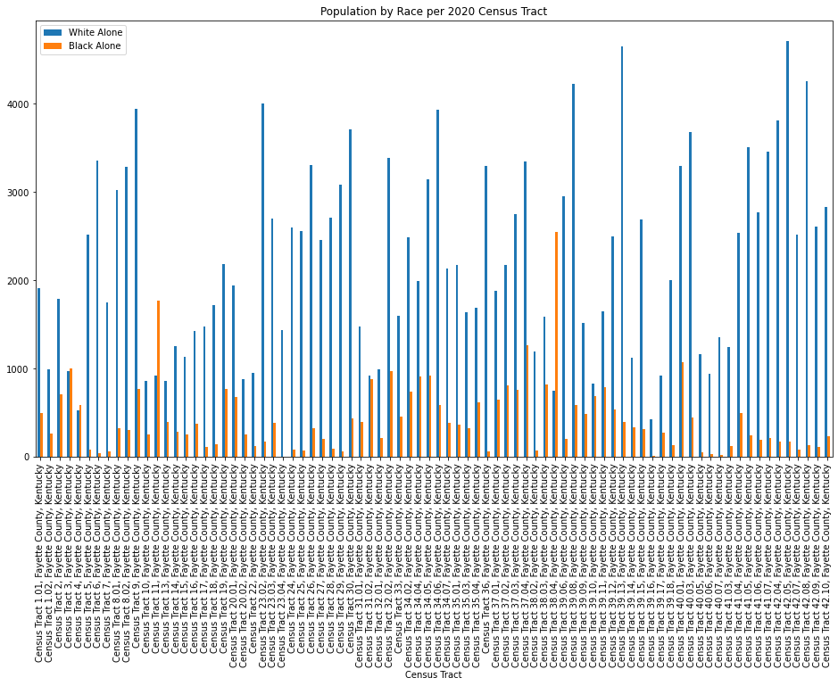

```python
#double bar graph to plot race by tract
race_bw_df.plot(y=['White Alone','Black Alone'],
                x='Census Tract',
                kind='bar',
                figsize=(16,9),
                title='Population by Race per 2020 Census Tract');

plt.show()
```

Need to add geolocation for the census tracts. Then map and clip only those tracts within New Circle

## Census Bureau Tract Data 2019

Examine the Census Bureau Shapefile Census tracts.

Import packages

```python
#Import necessary packages
%matplotlib inline
import pandas as pd
import geopandas as gpd
```

Load Data

```python
# import data & confirm GeoPandas works
cb_tracts_2019_ky_gdf = gpd.read_file('./data/cb_2019_tract_500k/cb_2019_21_tract_500k.shp')
cb_tracts_2019_ky_gdf.head()
```

|  | STATEFP | COUNTYFP | TRACTCE | AFFGEOID | GEOID | NAME | LSAD | ALAND | AWATER | geometry |
| --- | --- | --- | --- | --- | --- | --- | --- | --- | --- | --- |
| 0 | 21 | 089 | 040502 | 1400000US21089040502 | 21089040502 | 405.02 | CT | 248542928 | 4123331 | POLYGON ((-83.05044 38.46728, -83.04835 38.467... |
| 1 | 21 | 087 | 930100 | 1400000US21087930100 | 21087930100 | 9301 | CT | 253771498 | 2116317 | POLYGON ((-85.69732 37.30184, -85.68857 37.352... |
| 2 | 21 | 111 | 012601 | 1400000US21111012601 | 21111012601 | 126.01 | CT | 4460299 | 5315 | POLYGON ((-85.84257 38.19537, -85.83500 38.201... |
| 3 | 21 | 111 | 012302 | 1400000US21111012302 | 21111012302 | 123.02 | CT | 4811351 | 28216 | POLYGON ((-85.82930 38.15719, -85.82586 38.162... |
| 4 | 21 | 099 | 970300 | 1400000US21099970300 | 21099970300 | 9703 | CT | 256953396 | 5843968 | POLYGON ((-86.16112 37.35080, -86.15845 37.351... |

First glimpse; Data types

```python
# determine data types working with
cb_tracts_2019_ky_gdf.info() #currently 1115 entries
```

```
<class 'geopandas.geodataframe.GeoDataFrame'>
RangeIndex: 1115 entries, 0 to 1114
Data columns (total 10 columns):
 #   Column    Non-Null Count  Dtype
---  ------    --------------  -----
 0   STATEFP   1115 non-null   object
 1   COUNTYFP  1115 non-null   object
 2   TRACTCE   1115 non-null   object
 3   AFFGEOID  1115 non-null   object
 4   GEOID     1115 non-null   object
 5   NAME      1115 non-null   object
 6   LSAD      1115 non-null   object
 7   ALAND     1115 non-null   int64
 8   AWATER    1115 non-null   int64
 9   geometry  1115 non-null   geometry
dtypes: geometry(1), int64(2), object(7)
memory usage: 87.2+ KB
```

Drop all Tracts whose COUNTYFP does not equal Fayette County (i.e. 067). Currently contains ALL Kentucky tracts.

```python
# convert STATEFP from object to string
cb_tracts_2019_ky_gdf['COUNTYFP']=cb_tracts_2019_ky_gdf['COUNTYFP'].astype(str)

# assign and pull out all rows associated with fayette (21)
cb_tracts_2019_fayette_gdf = cb_tracts_2019_ky_gdf[cb_tracts_2019_ky_gdf.COUNTYFP == '067']
```

```python
# confirm creation of new geodataframe with KY only data
cb_tracts_2019_fayette_gdf.info() #now only 82 entries which matches the number of entries in pandas dataframe above
```

```
<class 'geopandas.geodataframe.GeoDataFrame'>
Int64Index: 82 entries, 23 to 1112
Data columns (total 10 columns):
 #   Column    Non-Null Count  Dtype
---  ------    --------------  -----
 0   STATEFP   82 non-null     object
 1   COUNTYFP  82 non-null     object
 2   TRACTCE   82 non-null     object
 3   AFFGEOID  82 non-null     object
 4   GEOID     82 non-null     object
 5   NAME      82 non-null     object
 6   LSAD      82 non-null     object
 7   ALAND     82 non-null     int64
 8   AWATER    82 non-null     int64
 9   geometry  82 non-null     geometry
dtypes: geometry(1), int64(2), object(7)
memory usage: 7.0+ KB
```

Glimpse headers of Fayette County Census Tracts

```python
# review headers
cb_tracts_2019_fayette_gdf.head()
```

|  | STATEFP | COUNTYFP | TRACTCE | AFFGEOID | GEOID | NAME | LSAD | ALAND | AWATER | geometry |
| --- | --- | --- | --- | --- | --- | --- | --- | --- | --- | --- |
| 23 | 21 | 067 | 001500 | 1400000US21067001500 | 21067001500 | 15 | CT | 1968316 | 0 | POLYGON ((-84.47247 38.05277, -84.47135 38.053... |
| 26 | 21 | 067 | 003202 | 1400000US21067003202 | 21067003202 | 32.02 | CT | 3028160 | 0 | POLYGON ((-84.46479 38.06010, -84.45494 38.063... |
| 30 | 21 | 067 | 003914 | 1400000US21067003914 | 21067003914 | 39.14 | CT | 1340775 | 0 | POLYGON ((-84.41176 38.02212, -84.40621 38.025... |
| 31 | 21 | 067 | 001900 | 1400000US21067001900 | 21067001900 | 19 | CT | 2300743 | 0 | POLYGON ((-84.54345 38.04757, -84.54265 38.047... |
| 43 | 21 | 067 | 003201 | 1400000US21067003201 | 21067003201 | 32.01 | CT | 1982605 | 0 | POLYGON ((-84.47185 38.06696, -84.46873 38.067... |

Won't need all attributes. Drop those not necessary for project completion.

```python
# drop excess columns

# To Drop Columns state fips code, county fips code, area water, legal statistical area description (census tract)
to_drop2 = ['STATEFP', 'COUNTYFP', 'AWATER', 'LSAD']

# drop excess columns from geodataframe
# assign remaining data to new dataframe name
cb_tracts_2019_fayette_gdf_min = cb_tracts_2019_fayette_gdf.drop(to_drop2, axis=1)
```

```python
#confirm drop
cb_tracts_2019_fayette_gdf_min.head()
```

|  | TRACTCE | AFFGEOID | GEOID | NAME | ALAND | geometry |
| --- | --- | --- | --- | --- | --- | --- |
| 23 | 001500 | 1400000US21067001500 | 21067001500 | 15 | 1968316 | POLYGON ((-84.47247 38.05277, -84.47135 38.053... |
| 26 | 003202 | 1400000US21067003202 | 21067003202 | 32.02 | 3028160 | POLYGON ((-84.46479 38.06010, -84.45494 38.063... |
| 30 | 003914 | 1400000US21067003914 | 21067003914 | 39.14 | 1340775 | POLYGON ((-84.41176 38.02212, -84.40621 38.025... |
| 31 | 001900 | 1400000US21067001900 | 21067001900 | 19 | 2300743 | POLYGON ((-84.54345 38.04757, -84.54265 38.047... |
| 43 | 003201 | 1400000US21067003201 | 21067003201 | 32.01 | 1982605 | POLYGON ((-84.47185 38.06696, -84.46873 38.067... |

## Merge Race/Segregation Data & Census Bureau Tract Data

Want to have geolocated/assigned data. So need to merge the geodataframe of census bureau tracts with race/segregation dataframe data above.

```python
#rename AFFGEOID to GEO_ID so can merge with race_bw_df
cb_tracts_2019_fayette_gdf_min.rename(columns={'AFFGEOID':'GEO_ID'}, inplace=True)
```

```python
#confirm column name change
cb_tracts_2019_fayette_gdf_min.head()
```

|  | TRACTCE | GEO_ID | GEOID | NAME | ALAND | geometry |
| --- | --- | --- | --- | --- | --- | --- |
| 23 | 001500 | 1400000US21067001500 | 21067001500 | 15 | 1968316 | POLYGON ((-84.47247 38.05277, -84.47135 38.053... |
| 26 | 003202 | 1400000US21067003202 | 21067003202 | 32.02 | 3028160 | POLYGON ((-84.46479 38.06010, -84.45494 38.063... |
| 30 | 003914 | 1400000US21067003914 | 21067003914 | 39.14 | 1340775 | POLYGON ((-84.41176 38.02212, -84.40621 38.025... |
| 31 | 001900 | 1400000US21067001900 | 21067001900 | 19 | 2300743 | POLYGON ((-84.54345 38.04757, -84.54265 38.047... |
| 43 | 003201 | 1400000US21067003201 | 21067003201 | 32.01 | 1982605 | POLYGON ((-84.47185 38.06696, -84.46873 38.067... |

Merge pandas dataframe for census data by race with geopandas dataframe of census bureau tracts using GEO_ID

```python
#race_bw_df merge with cb_tracts_2019_fayette_gdf_min
race_cb_tracts_2019_gdf = cb_tracts_2019_fayette_gdf_min.merge(race_bw_df, on = 'GEO_ID')
```

Confirm merge

```python
#confirm merge by entries
race_cb_tracts_2019_gdf.head()
race_cb_tracts_2019_gdf.info() #82 entries available just like in race_bw_df 7.0KB
```

```
<class 'geopandas.geodataframe.GeoDataFrame'>
Int64Index: 82 entries, 0 to 81
Data columns (total 10 columns):
 #   Column        Non-Null Count  Dtype
---  ------        --------------  -----
 0   TRACTCE       82 non-null     object
 1   GEO_ID        82 non-null     object
 2   GEOID         82 non-null     object
 3   NAME          82 non-null     object
 4   ALAND         82 non-null     int64
 5   geometry      82 non-null     geometry
 6   Census Tract  82 non-null     object
 7   Total         82 non-null     float64
 8   White Alone   82 non-null     float64
 9   Black Alone   82 non-null     float64
dtypes: float64(3), geometry(1), int64(1), object(5)
memory usage: 7.0+ KB
```

```python
#glimpse headers
race_cb_tracts_2019_gdf.head(5)
```

|  | TRACTCE | GEO_ID | GEOID | NAME | ALAND | geometry | Census Tract | Total | White Alone | Black Alone |
| --- | --- | --- | --- | --- | --- | --- | --- | --- | --- | --- |
| 0 | 001500 | 1400000US21067001500 | 21067001500 | 15 | 1968316 | POLYGON ((-84.47247 38.05277, -84.47135 38.053... | Census Tract 15, Fayette County, Kentucky | 1651.0 | 1131.0 | 252.0 |
| 1 | 003202 | 1400000US21067003202 | 21067003202 | 32.02 | 3028160 | POLYGON ((-84.46479 38.06010, -84.45494 38.063... | Census Tract 32.02, Fayette County, Kentucky | 5084.0 | 3386.0 | 973.0 |
| 2 | 003914 | 1400000US21067003914 | 21067003914 | 39.14 | 1340775 | POLYGON ((-84.41176 38.02212, -84.40621 38.025... | Census Tract 39.14, Fayette County, Kentucky | 1750.0 | 1124.0 | 333.0 |
| 3 | 001900 | 1400000US21067001900 | 21067001900 | 19 | 2300743 | POLYGON ((-84.54345 38.04757, -84.54265 38.047... | Census Tract 19, Fayette County, Kentucky | 3818.0 | 2189.0 | 767.0 |
| 4 | 003201 | 1400000US21067003201 | 21067003201 | 32.01 | 1982605 | POLYGON ((-84.47185 38.06696, -84.46873 38.067... | Census Tract 32.01, Fayette County, Kentucky | 1348.0 | 990.0 | 214.0 |

### Map Race/Segregation Data

```python
# determine epsg for gdf
print('Race Census Bureau Tracts CRS=', race_cb_tracts_2019_gdf.crs)
```

```
Race Census Bureau Tracts CRS= epsg:4269
```

CRS 4269 utilizes unit in degrees. Need to transform to 2205 for meters (geopandas/shapely assume their set of operations are being used in meters).

```python
#convert epsg 4269 to epsg 2205
crs = {'init' : 'epsg:2205'}
race_tracts_2019_geo = race_cb_tracts_2019_gdf.to_crs(crs)
```

```python
# confirm conversion
print('Race Census Bureau Tracts CRS=', race_tracts_2019_geo.crs)
```

```
Race Census Bureau Tracts CRS= +init=epsg:2205 +type=crs
```

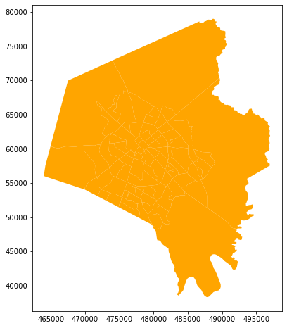

```python
# plot all census tracts for fayette county
fig, ax = plt.subplots(figsize=(12, 8))

race_tracts_2019_geo.plot(ax=ax, color='orange', zorder=0,);
```

Confirm unique values named using new CRS geo layer

```python
print(race_tracts_2019_geo['NAME'].unique())
print(race_tracts_2019_geo['NAME'].count())
```

```
['15' '32.02' '39.14' '19' '32.01' '29' '40.01' '20.02' '31.01' '11'
 '42.09' '33' '4' '39.11' '40.03' '41.03' '39.10' '7' '28' '41.07' '22'
 '16' '42.04' '8.01' '13' '2' '35.01' '42.08' '34.02' '39.08' '39.13' '9'
 '41.04' '24' '18' '5' '41.05' '1.02' '34.04' '27' '38.03' '38.04' '23.02'
 '35.04' '42.05' '40.06' '36' '25' '35.03' '39.17' '40.07' '23.03' '42.10'
 '8.02' '38.02' '37.02' '1.01' '40.05' '41.06' '17' '34.07' '39.12'
 '39.09' '34.05' '39.16' '6' '34.06' '37.03' '31.02' '42.07' '23.04'
 '37.04' '20.01' '14' '30' '10' '39.18' '39.15' '3' '37.01' '26' '39.06']
82
```

Need to clip to census tracts within new circle road of Lexington to reduce file size and limit area of interest to those necessary for HOLC graded neighborhoods. Best plan of action is to create a shapefile for new circle road using qgis then load to notebook for clipping purposes.

#### Clipping to New Circle

Load New Circle Shapefile created in QGIS. New Circle Shapefile was created using a rough drawn outline of the New Circle Road. An arbitrarily assigned restriction as the road circles the bulk of town and thought it would be a could restrictive boundary to decrease the number of tracts analyzed.

Load Shapefile Data

```python
# import data & confirm GeoPandas works
new_circle_gdf = gpd.read_file('./data/new_circle/new_circle_road.shp')
new_circle_gdf.head()
```

|  | id | geometry |
| --- | --- | --- |
| 0 | 1 | POLYGON ((-84.55734 38.02482, -84.55984 38.026... |

Glimpse data

```python
# view data types
new_circle_gdf.info()
```

```
<class 'geopandas.geodataframe.GeoDataFrame'>
RangeIndex: 1 entries, 0 to 0
Data columns (total 2 columns):
 #   Column    Non-Null Count  Dtype
---  ------    --------------  -----
 0   id        1 non-null      int64
 1   geometry  1 non-null      geometry
dtypes: geometry(1), int64(1)
memory usage: 144.0 bytes
```

View New Circle CRS

```python
print('New Circle CRS=', new_circle_gdf.crs)
```

```
New Circle CRS= epsg:4326
```

Convert CRS from 4326 to 2205 to matche race/census tracts CRS for plotting

```python
#convert crs
crs = {'init' : 'epsg:2205'}
new_circle_geo = new_circle_gdf.to_crs(crs)
```

```python
print('New Circle CRS=', new_circle_geo.crs)
```

```
New Circle CRS= +init=epsg:2205 +type=crs
```

Plot shapefile

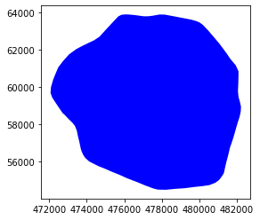

```python
fig, ax = plt.subplots()
new_circle_geo.plot(ax=ax, color='blue', zorder=0,);
```

Plot both inside New Circle Road and Census Tracts to see how much data will be reduced when clipping to New Circle Road.

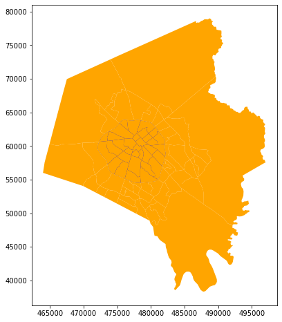

```python
#Plot both new circle and census tracts
fig, ax = plt.subplots(figsize=(12, 8))
new_circle_geo.plot(ax=ax, color='blue', zorder=0,);
race_tracts_2019_geo.plot(ax=ax, color='orange', zorder=1,);
```

Confirm new_circle_geo polygon type

```python
# Double check new_circle_geo only has one polygon type (either polygon or multiplogyon types not both)
new_circle_geo.geom_type.unique()
```

```
array(['Polygon'], dtype=object)
```

Create polygon mask

```python
# use unary_union to combine polygon into single polygon mask to clip by
new_circle_geo_poly = new_circle_geo.geometry.unary_union
```

Clip using new_circle_geo_poly mask

```python
#using new circle poly layer, clip each census tract
new_circle_race_tracts = race_tracts_2019_geo[race_tracts_2019_geo.intersects(new_circle_geo_poly)]
```

Plot both new circle and clipped tracts

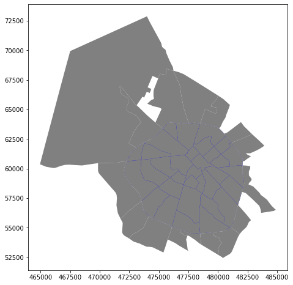

```python
#Plot both new circle and newly clipped tracts
fig, ax = plt.subplots(figsize=(12, 8))
new_circle_geo.plot(ax=ax, color='blue', zorder=0,);
new_circle_race_tracts.plot(ax=ax, color='grey', zorder=1,);
```

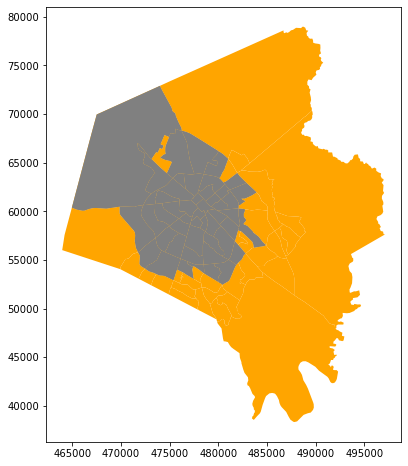

```python
#Plot both old and new census tracts to confirm clip accuracy
fig, ax = plt.subplots(figsize=(12, 8))
race_tracts_2019_geo.plot(ax=ax, color='orange', zorder=0,);
new_circle_race_tracts.plot(ax=ax, color='grey', zorder=1,);
```

Still pulling more area than prefer, but may still need to keep the outside areas as they are tracts that do intersect with new circle. Another thought is to clip this further with only the HOLC graded neighborhoods...caveat here is would end up missing unique interpretations that could be made about surrounding neighborhoods that grew up after HOLC grading.

```python
# glimpse merged/clipped geopandas dataframe
new_circle_race_tracts.info() #race tracts reduced from 82 entries to 49 and 4.2KB
```

```
<class 'geopandas.geodataframe.GeoDataFrame'>
Int64Index: 49 entries, 0 to 80
Data columns (total 10 columns):
 #   Column        Non-Null Count  Dtype
---  ------        --------------  -----
 0   TRACTCE       49 non-null     object
 1   GEO_ID        49 non-null     object
 2   GEOID         49 non-null     object
 3   NAME          49 non-null     object
 4   ALAND         49 non-null     int64
 5   geometry      49 non-null     geometry
 6   Census Tract  49 non-null     object
 7   Total         49 non-null     float64
 8   White Alone   49 non-null     float64
 9   Black Alone   49 non-null     float64
dtypes: float64(3), geometry(1), int64(1), object(5)
memory usage: 4.2+ KB
```

```python
new_circle_race_tracts.head()
```

|  | TRACTCE | GEO_ID | GEOID | NAME | ALAND | geometry | Census Tract | Total | White Alone | Black Alone |
| --- | --- | --- | --- | --- | --- | --- | --- | --- | --- | --- |
| 0 | 001500 | 1400000US21067001500 | 21067001500 | 15 | 1968316 | POLYGON ((480474.524 61378.770, 480572.928 614... | Census Tract 15, Fayette County, Kentucky | 1651.0 | 1131.0 | 252.0 |
| 1 | 003202 | 1400000US21067003202 | 21067003202 | 32.02 | 3028160 | POLYGON ((481149.868 62191.215, 482015.597 625... | Census Tract 32.02, Fayette County, Kentucky | 5084.0 | 3386.0 | 973.0 |
| 3 | 001900 | 1400000US21067001900 | 21067001900 | 19 | 2300743 | POLYGON ((474242.468 60819.375, 474312.809 608... | Census Tract 19, Fayette County, Kentucky | 3818.0 | 2189.0 | 767.0 |
| 4 | 003201 | 1400000US21067003201 | 21067003201 | 32.01 | 1982605 | POLYGON ((480532.121 62954.227, 480806.698 630... | Census Tract 32.01, Fayette County, Kentucky | 1348.0 | 990.0 | 214.0 |
| 5 | 002900 | 1400000US21067002900 | 21067002900 | 29 | 3179556 | POLYGON ((473557.126 57277.354, 473740.056 574... | Census Tract 29, Fayette County, Kentucky | 3363.0 | 3085.0 | 59.0 |

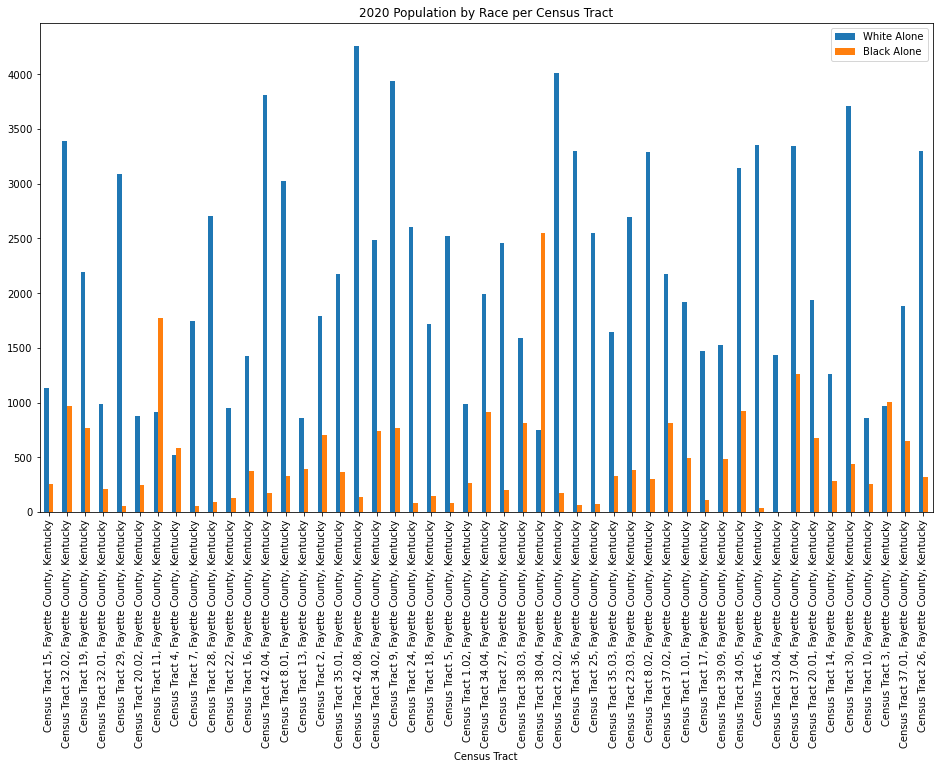

```python
#double bar graph to plot race by clipped tracts
new_circle_race_tracts.plot(y=['White Alone','Black Alone'],
                x='Census Tract',
                kind='bar',
                figsize=(16,9),
                title='2020 Population by Race per Census Tract');

plt.show()
```

Utilizing New Circle to clip census tracts is still picking up more than really is necessary. Will continue by clipping to the HOLC graded neighborhoods instead to see how much would be lost and if larger picture would still be available. Could always add buffer to clip by, but would most likely end up with the same tracts as is currently pictured in new_circle_race_tracts.

#### Clip by HOLC neighborhoods

Load HOLC Data to attempt a new clip of census tracts

```python
# import data & confirm GeoPandas works
holc_gdf = gpd.read_file('./data/KYLexington1936.geojson')
```

Glimpse HOLC data

```python
holc_gdf.head()
```

|  | name | holc_id | holc_grade | area_description_data | geometry |
| --- | --- | --- | --- | --- | --- |
| 0 | None | A1 | A | {'': ''} | MULTIPOLYGON (((-84.51133 38.01811, -84.51211 ... |
| 1 | None | A2 | A | {'': ''} | MULTIPOLYGON (((-84.49628 38.02381, -84.49376 ... |
| 2 | None | A3 | A | {'': ''} | MULTIPOLYGON (((-84.47662 38.02922, -84.47708 ... |
| 3 | None | A4 | A | {'': ''} | MULTIPOLYGON (((-84.47662 38.02922, -84.47470 ... |
| 4 | None | B1 | B | {'': ''} | MULTIPOLYGON (((-84.51276 38.03197, -84.50941 ... |

```python
holc_gdf.info() #29 entries; 4 objects 1 geometry 1.3 KB
```

```
<class 'geopandas.geodataframe.GeoDataFrame'>
RangeIndex: 29 entries, 0 to 28
Data columns (total 5 columns):
 #   Column                 Non-Null Count  Dtype
---  ------                 --------------  -----
 0   name                   0 non-null      object
 1   holc_id                29 non-null     object
 2   holc_grade             29 non-null     object
 3   area_description_data  29 non-null     object
 4   geometry               29 non-null     geometry
dtypes: geometry(1), object(4)
memory usage: 1.3+ KB
```

View HOLC CRS

```python
print('HOLC CRS=', holc_gdf.crs)
```

```
HOLC CRS= epsg:4326
```

```python
#convert crs to 2205
crs = {'init' : 'epsg:2205'}
holc_geo = holc_gdf.to_crs(crs)
```

```python
print('HOLC CRS=', holc_geo.crs)
```

```
HOLC CRS= +init=epsg:2205 +type=crs
```

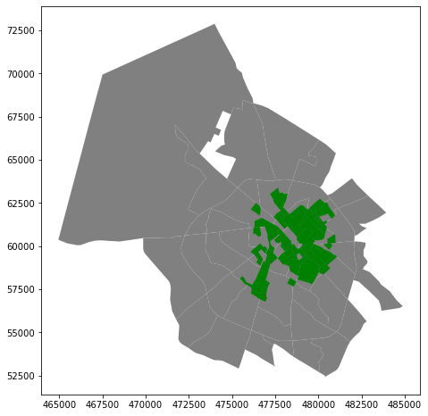

```python
# plot holc and clipped tracts to see if can reduce further
fig, ax = plt.subplots(figsize=(12, 8))
holc_geo.plot(ax=ax, color='green', zorder=1,);
new_circle_race_tracts.plot(ax=ax, color='grey', zorder=0,);
```

Much fewer tracts will be selected this way, and it will still maintain a fair amount surrounding areas. Will proceed with this method.

Confirm HOLC has one polygon type

```python
# Double check holc only has one polygon type (either polygon or multiplogyon types not both)
holc_geo.geom_type.unique() # only one polygon type, MultiPolygon
```

```
array(['MultiPolygon'], dtype=object)
```

Create HOLC polygon mask to clip by

```python
# use unary_union to combine Multipolygon into single polygon mask to clip by
holc_geo_poly = holc_geo.geometry.unary_union
```

```python
#using new holc_geo_poly layer, clip each census tract from previous new circl clip
holc_race_tracts = new_circle_race_tracts[new_circle_race_tracts.intersects(holc_geo_poly)]
```

View how much clipping by HOLC neighborhoods reduced tract data vs new circl clipped data

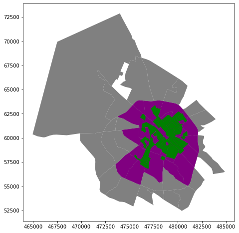

```python
# plot holc newly clipped race tracts
fig, ax = plt.subplots(figsize=(12, 8))
holc_race_tracts.plot(ax=ax, color='purple', zorder=1);
new_circle_race_tracts.plot(ax=ax, color='grey', zorder=0,);
holc_geo.plot(ax=ax, color='green', zorder=2,);
```

Have significantly reduced the number of tracts. Lets look into the info and headers now.

```python
holc_race_tracts.info() #reduced from 82 to 49 to now 27; and 7.0KB to 4.2KB to now 2.3KB
```

```
<class 'geopandas.geodataframe.GeoDataFrame'>
Int64Index: 27 entries, 0 to 78
Data columns (total 10 columns):
 #   Column        Non-Null Count  Dtype
---  ------        --------------  -----
 0   TRACTCE       27 non-null     object
 1   GEO_ID        27 non-null     object
 2   GEOID         27 non-null     object
 3   NAME          27 non-null     object
 4   ALAND         27 non-null     int64
 5   geometry      27 non-null     geometry
 6   Census Tract  27 non-null     object
 7   Total         27 non-null     float64
 8   White Alone   27 non-null     float64
 9   Black Alone   27 non-null     float64
dtypes: float64(3), geometry(1), int64(1), object(5)
memory usage: 2.3+ KB
```

```python
holc_race_tracts.head()
```

|  | TRACTCE | GEO_ID | GEOID | NAME | ALAND | geometry | Census Tract | Total | White Alone | Black Alone |
| --- | --- | --- | --- | --- | --- | --- | --- | --- | --- | --- |
| 0 | 001500 | 1400000US21067001500 | 21067001500 | 15 | 1968316 | POLYGON ((480474.524 61378.770, 480572.928 614... | Census Tract 15, Fayette County, Kentucky | 1651.0 | 1131.0 | 252.0 |
| 3 | 001900 | 1400000US21067001900 | 21067001900 | 19 | 2300743 | POLYGON ((474242.468 60819.375, 474312.809 608... | Census Tract 19, Fayette County, Kentucky | 3818.0 | 2189.0 | 767.0 |
| 5 | 002900 | 1400000US21067002900 | 21067002900 | 29 | 3179556 | POLYGON ((473557.126 57277.354, 473740.056 574... | Census Tract 29, Fayette County, Kentucky | 3363.0 | 3085.0 | 59.0 |
| 9 | 001100 | 1400000US21067001100 | 21067001100 | 11 | 3165953 | POLYGON ((476452.701 63851.280, 477230.313 637... | Census Tract 11, Fayette County, Kentucky | 3787.0 | 918.0 | 1774.0 |
| 12 | 000400 | 1400000US21067000400 | 21067000400 | 4 | 1185662 | POLYGON ((479310.644 60460.838, 479764.128 609... | Census Tract 4, Fayette County, Kentucky | 1288.0 | 524.0 | 587.0 |

List the unique census tract values remaining

```python
print('HOLC Census Tracts of Interest:', holc_race_tracts['NAME'].unique())
print('Total HOLC Census Tracts of Interest:', holc_race_tracts['NAME'].count())
```

```
HOLC Census Tracts of Interest: ['15' '19' '29' '11' '4' '7' '28' '22' '16' '8.01' '13' '2' '9' '24' '18'
 '5' '1.02' '25' '23.03' '8.02' '1.01' '17' '6' '23.04' '14' '10' '3']
Total HOLC Census Tracts of Interest: 27
```

Plot census tract race/segregation values

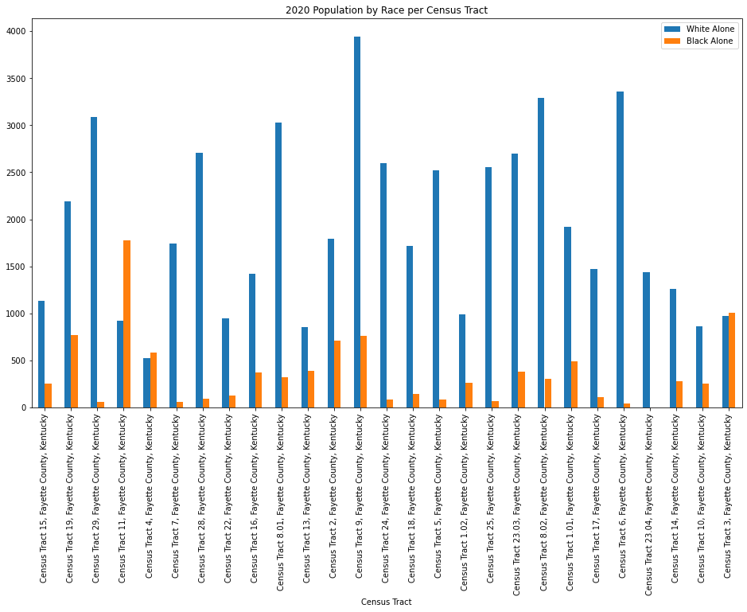

```python
#double bar graph to plot race by clipped tracts
holc_race_tracts.plot(y=['White Alone','Black Alone'],
                x='Census Tract',
                kind='bar',
                figsize=(16,9),
                title='2020 Population by Race per Census Tract');

plt.show()
```

Write gdf to GeoJSON file in the event refernce later is needed.

```python
holc_race_tracts.to_file('./data//holc_race_tracts_json.json', driver='GeoJSON')
```

## Median Household Income

In the previous section was able to clip data from the entirety of Fayette County down to census tracts of interest, also known as, census tracts in/intersecting with the HOLC identified neighborhoods. With the list of census tracts will only pull those tracts going forward (as is an option at US Census Bureau site (data.census.gov) under the Geography filter). This should expedite the cleaning of data sets.

Load data

```python
# load csv data as pandas dataframe
med_income_2019_df = pd.read_csv('./data/med_income_2019_5y/ACSST5Y2019.S1901_data_with_overlays.csv')
```

```python
# verify med_income_2019_df references pandas Dataframe object, not CSV file
type(med_income_2019_df)
```

```
pandas.core.frame.DataFrame
```

First glimpse data

```python
# get idea for starting place of data
med_income_2019_df.info()
#28 entries
# 130 columns
```

```
<class 'pandas.core.frame.DataFrame'>
RangeIndex: 28 entries, 0 to 27
Columns: 130 entries, GEO_ID to S1901_C04_016M
dtypes: object(130)
memory usage: 28.6+ KB
```

View first 5 rows and headers

```python
# initial look at data with first 5 rows
med_income_2019_df.head(5)
```

|  | GEO_ID | NAME | S1901_C01_001E | S1901_C01_001M | S1901_C01_002E | S1901_C01_002M | S1901_C01_003E | S1901_C01_003M | S1901_C01_004E | S1901_C01_004M | S1901_C01_005E | S1901_C01_005M | S1901_C01_006E | S1901_C01_006M | S1901_C01_007E | S1901_C01_007M | S1901_C01_008E | S1901_C01_008M | S1901_C01_009E | S1901_C01_009M | S1901_C01_010E | S1901_C01_010M | S1901_C01_011E | S1901_C01_011M | S1901_C01_012E | S1901_C01_012M | S1901_C01_013E | S1901_C01_013M | S1901_C01_014E | … |
| --- | --- | --- | --- | --- | --- | --- | --- | --- | --- | --- | --- | --- | --- | --- | --- | --- | --- | --- | --- | --- | --- | --- | --- | --- | --- | --- | --- | --- | --- | --- |
| 0 | id | Geographic Area Name | Estimate!!Households!!Total | Margin of Error!!Households!!Total | Estimate!!Households!!Total!!Less than $10,000 | Margin of Error!!Households!!Total!!Less than ... | Estimate!!Households!!Total!!$10,000 to $14,999 | Margin of Error!!Households!!Total!!$10,000 to... | Estimate!!Households!!Total!!$15,000 to $24,999 | Margin of Error!!Households!!Total!!$15,000 to... | Estimate!!Households!!Total!!$25,000 to $34,999 | Margin of Error!!Households!!Total!!$25,000 to... | Estimate!!Households!!Total!!$35,000 to $49,999 | Margin of Error!!Households!!Total!!$35,000 to... | Estimate!!Households!!Total!!$50,000 to $74,999 | Margin of Error!!Households!!Total!!$50,000 to... | Estimate!!Households!!Total!!$75,000 to $99,999 | Margin of Error!!Households!!Total!!$75,000 to... | Estimate!!Households!!Total!!$100,000 to $149,999 | Margin of Error!!Households!!Total!!$100,000 t... | Estimate!!Households!!Total!!$150,000 to $199,999 | Margin of Error!!Households!!Total!!$150,000 t... | Estimate!!Households!!Total!!$200,000 or more | Margin of Error!!Households!!Total!!$200,000 o... | Estimate!!Households!!Median income (dollars) | Margin of Error!!Households!!Median income (do... | Estimate!!Households!!Mean income (dollars) | Margin of Error!!Households!!Mean income (doll... | Estimate!!Households!!PERCENT ALLOCATED!!House... | … |
| 1 | 1400000US21067000101 | Census Tract 1.01, Fayette County, Kentucky | 1993 | 120 | 21.7 | 6.4 | 10.9 | 5.3 | 17.2 | 4.7 | 9.4 | 3.6 | 10.4 | 3.9 | 10.3 | 3.6 | 5.6 | 3.4 | 5.9 | 2.4 | 3.6 | 1.9 | 5.0 | 2.6 | 25363 | 7664 | 52628 | 7896 | 20.5 | … |
| 2 | 1400000US21067000102 | Census Tract 1.02, Fayette County, Kentucky | 984 | 108 | 22.4 | 6.7 | 16.9 | 6.7 | 8.1 | 4.2 | 13.9 | 7.3 | 7.5 | 5.0 | 9.1 | 5.6 | 6.2 | 3.4 | 8.7 | 5.0 | 2.3 | 2.3 | 4.8 | 2.8 | 26477 | 4397 | 53200 | 10180 | 28.3 | … |
| 3 | 1400000US21067000200 | Census Tract 2, Fayette County, Kentucky | 1225 | 128 | 11.6 | 5.5 | 10.3 | 6.0 | 23.7 | 6.7 | 15.0 | 6.6 | 17.0 | 7.4 | 12.5 | 5.5 | 1.6 | 1.6 | 4.2 | 2.9 | 0.0 | 2.4 | 4.2 | 2.6 | 26725 | 6408 | 45985 | 8657 | 36.9 | … |
| 4 | 1400000US21067000300 | Census Tract 3, Fayette County, Kentucky | 1249 | 99 | 15.7 | 6.0 | 6.1 | 5.3 | 14.8 | 5.6 | 17.8 | 7.7 | 20.8 | 7.3 | 13.1 | 5.5 | 3.4 | 2.7 | 6.2 | 4.4 | 0.7 | 1.2 | 1.3 | 1.5 | 32089 | 4708 | 42376 | 7148 | 35.0 | … |

In first glance know will need to remove attributes/columns not pertaining to this project.

- Glossary can be found in './data/med_income_2019_5y/ACSST5Y2019_metadata.csv'
- Drop the following:
  - Attributes pertaining to percent allocated (can always be found in US Census raw data file) All S1901_C01 to S1901_C04 with 014E-106E
  - Attributes referencing margin of error (can always be found in US Census raw data file):
    - S1901_C01_001M, S1901_C01_002M, S1901_C01_003M, S1901_C01_004M, S1901_C01_005M, S1901_C01_006M, S1901_C01_007M, S1901_C01_008M, S1901_C01_009M, S1901_C01_010M, S1901_C01_011M, S1901_C01_012M, S1901_C01_013M, S1901_C01_014M, S1901_C01_015M, S1901_C01_016M
    - S1901_C02_001M, S1901_C02_002M, S1901_C02_003M, S1901_C02_004M, S1901_C02_005M, S1901_C02_006M, S1901_C02_007M, S1901_C02_008M, S1901_C02_009M, S1901_C02_010M, S1901_C02_011M, S1901_C02_012M, S1901_C02_013M, S1901_C02_014M, S1901_C02_015M, S1901_C02_016M
    - S1901_C03_001M, S1901_C03_002M, S1901_C03_003M, S1901_C03_004M, S1901_C03_005M, S1901_C03_006M, S1901_C03_007M, S1901_C03_008M, S1901_C03_009M, S1901_C03_010M, S1901_C03_011M, S1901_C03_012M, S1901_C03_013M, S1901_C03_014M, S1901_C03_015M, S1901_C03_016M
    - S1901_C04_001M, S1901_C04_002M, S1901_C04_003M, S1901_C04_004M, S1901_C04_005M, S1901_C04_006M, S1901_C04_007M, S1901_C04_008M, S1901_C04_009M, S1901_C04_010M, S1901_C04_011M, S1901_C04_012M, S1901_C04_013M
- Should combine and reduce the number of categories for median income currently have a separate category for each of the following
  - < 10,000
  - 10,000 - 14,999
  - 15,000 - 24,999
  - 25,000 - 34,999
  - 35,000 - 49,999
  - 50,000 - 74,999
  - 75,000 - 99,999
  - 100,000 - 149,999
  - 150,000 - 199,999
  - 200,000 +  
    -The challenge here is that if we try to base it on the poverty line that is determined by number of persons per household and that data isn't included in this current survey. The median household income for Kentucky (in [2019 dollars from 2015-2019](https://www.census.gov/quickfacts/fact/table/KY/POP060210) was 50,589.
  - Considering combining everything below 24,999 into one categroy. Reasoning being the federal poverty level for household income for individuals up to a family of 4, included 2021 income being at 26,500 and below. (https://www.healthcare.gov/glossary/federal-poverty-level-fpl/)
  - Also thinking of combining 25,000 to 49,999 as family sizes of 5-9 fall into this category for federal poverty levels at the same site above).
  - Then leave the remaining 25,000 increments as currently indicated.

Will need to confirm the census tracts that were supposed to be included were actually downloaded. Will need to rename the attributes/column based on their correct header info (then can delete the row that contains this information)

### Drop Attributes/Columns

```python
# to drop columns
to_drop3 = ['S1901_C01_014E', 'S1901_C01_015E', 'S1901_C01_016E', 'S1901_C02_014E', 'S1901_C02_015E',
           'S1901_C02_016E', 'S1901_C03_014E', 'S1901_C03_015E', 'S1901_C03_016E', 'S1901_C04_014E',
           'S1901_C04_015E', 'S1901_C04_016E',
           'S1901_C01_001M', 'S1901_C01_002M', 'S1901_C01_003M', 'S1901_C01_004M', 'S1901_C01_005M', 'S1901_C01_006M',
           'S1901_C01_007M', 'S1901_C01_008M', 'S1901_C01_009M', 'S1901_C01_010M', 'S1901_C01_011M', 'S1901_C01_012M',
           'S1901_C01_013M', 'S1901_C01_014M', 'S1901_C01_015M', 'S1901_C01_016M', 'S1901_C02_001M', 'S1901_C02_002M',
           'S1901_C02_003M', 'S1901_C02_004M', 'S1901_C02_005M', 'S1901_C02_006M', 'S1901_C02_007M', 'S1901_C02_008M',
           'S1901_C02_009M', 'S1901_C02_010M', 'S1901_C02_011M', 'S1901_C02_012M', 'S1901_C02_013M', 'S1901_C02_014M',
           'S1901_C02_015M', 'S1901_C02_016M', 'S1901_C03_001M', 'S1901_C03_002M', 'S1901_C03_003M', 'S1901_C03_004M',
           'S1901_C03_005M', 'S1901_C03_006M', 'S1901_C03_007M', 'S1901_C03_008M', 'S1901_C03_009M', 'S1901_C03_010M',
           'S1901_C03_011M', 'S1901_C03_012M', 'S1901_C03_013M', 'S1901_C03_014M', 'S1901_C03_015M', 'S1901_C03_016M',
           'S1901_C04_001M', 'S1901_C04_002M', 'S1901_C04_003M', 'S1901_C04_004M', 'S1901_C04_005M', 'S1901_C04_006M',
           'S1901_C04_007M', 'S1901_C04_008M', 'S1901_C04_009M', 'S1901_C04_010M', 'S1901_C04_011M', 'S1901_C04_012M',
           'S1901_C04_013M', 'S1901_C04_014M', 'S1901_C04_015M', 'S1901_C04_016M'
    ] # columns to drop

#drop excess columns for data frame
#assign remaining data to new dataframe name
med_inc_19_df =  med_income_2019_df.drop(to_drop3, axis=1) #med_income_2019_df
```

Confirm drop

```python
# confirm colume/attribute drops
med_inc_19_df.head(5)
```

|  | GEO_ID | NAME | S1901_C01_001E | S1901_C01_002E | S1901_C01_003E | S1901_C01_004E | S1901_C01_005E | S1901_C01_006E | S1901_C01_007E | S1901_C01_008E | S1901_C01_009E | S1901_C01_010E | S1901_C01_011E | S1901_C01_012E | S1901_C01_013E | S1901_C02_001E | S1901_C02_002E | S1901_C02_003E | S1901_C02_004E | S1901_C02_005E | S1901_C02_006E | S1901_C02_007E | S1901_C02_008E | S1901_C02_009E | S1901_C02_010E | S1901_C02_011E | S1901_C02_012E | S1901_C02_013E | S1901_C03_001E | … |
| --- | --- | --- | --- | --- | --- | --- | --- | --- | --- | --- | --- | --- | --- | --- | --- | --- | --- | --- | --- | --- | --- | --- | --- | --- | --- | --- | --- | --- | --- | --- |
| 0 | id | Geographic Area Name | Estimate!!Households!!Total | Estimate!!Households!!Total!!Less than $10,000 | Estimate!!Households!!Total!!$10,000 to $14,999 | Estimate!!Households!!Total!!$15,000 to $24,999 | Estimate!!Households!!Total!!$25,000 to $34,999 | Estimate!!Households!!Total!!$35,000 to $49,999 | Estimate!!Households!!Total!!$50,000 to $74,999 | Estimate!!Households!!Total!!$75,000 to $99,999 | Estimate!!Households!!Total!!$100,000 to $149,999 | Estimate!!Households!!Total!!$150,000 to $199,999 | Estimate!!Households!!Total!!$200,000 or more | Estimate!!Households!!Median income (dollars) | Estimate!!Households!!Mean income (dollars) | Estimate!!Families!!Total | Estimate!!Families!!Total!!Less than $10,000 | Estimate!!Families!!Total!!$10,000 to $14,999 | Estimate!!Families!!Total!!$15,000 to $24,999 | Estimate!!Families!!Total!!$25,000 to $34,999 | Estimate!!Families!!Total!!$35,000 to $49,999 | Estimate!!Families!!Total!!$50,000 to $74,999 | Estimate!!Families!!Total!!$75,000 to $99,999 | Estimate!!Families!!Total!!$100,000 to $149,999 | Estimate!!Families!!Total!!$150,000 to $199,999 | Estimate!!Families!!Total!!$200,000 or more | Estimate!!Families!!Median income (dollars) | Estimate!!Families!!Mean income (dollars) | Estimate!!Married-couple families!!Total | … |
| 1 | 1400000US21067000101 | Census Tract 1.01, Fayette County, Kentucky | 1993 | 21.7 | 10.9 | 17.2 | 9.4 | 10.4 | 10.3 | 5.6 | 5.9 | 3.6 | 5.0 | 25363 | 52628 | 437 | 8.9 | 4.1 | 14.9 | 3.0 | 1.8 | 20.1 | 8.0 | 13.5 | 12.1 | 13.5 | 66813 | 108023 | 247 | … |
| 2 | 1400000US21067000102 | Census Tract 1.02, Fayette County, Kentucky | 984 | 22.4 | 16.9 | 8.1 | 13.9 | 7.5 | 9.1 | 6.2 | 8.7 | 2.3 | 4.8 | 26477 | 53200 | 187 | 4.3 | 15.5 | 3.7 | 14.4 | 8.0 | 0.0 | 20.9 | 16.6 | 0.0 | 16.6 | 80208 | 108877 | 148 | … |
| 3 | 1400000US21067000200 | Census Tract 2, Fayette County, Kentucky | 1225 | 11.6 | 10.3 | 23.7 | 15.0 | 17.0 | 12.5 | 1.6 | 4.2 | 0.0 | 4.2 | 26725 | 45985 | 477 | 4.8 | 17.8 | 28.3 | 2.9 | 11.7 | 19.7 | 0.8 | 6.1 | 0.0 | 7.8 | 22011 | 54601 | 196 | … |
| 4 | 1400000US21067000300 | Census Tract 3, Fayette County, Kentucky | 1249 | 15.7 | 6.1 | 14.8 | 17.8 | 20.8 | 13.1 | 3.4 | 6.2 | 0.7 | 1.3 | 32089 | 42376 | 557 | 7.9 | 5.9 | 18.1 | 19.2 | 21.4 | 12.9 | 1.6 | 10.1 | 0.0 | 2.9 | 31645 | 50658 | 167 | … |

```python
# confirm drop; 130 initial columns, less the dropped 76, should have 54 columns
med_inc_19_df.info() # 54 columns remain
```

```
<class 'pandas.core.frame.DataFrame'>
RangeIndex: 28 entries, 0 to 27
Data columns (total 54 columns):
 #   Column          Non-Null Count  Dtype
---  ------          --------------  -----
 0   GEO_ID          28 non-null     object
 1   NAME            28 non-null     object
 2   S1901_C01_001E  28 non-null     object
 3   S1901_C01_002E  28 non-null     object
 4   S1901_C01_003E  28 non-null     object
 5   S1901_C01_004E  28 non-null     object
 6   S1901_C01_005E  28 non-null     object
 7   S1901_C01_006E  28 non-null     object
 8   S1901_C01_007E  28 non-null     object
 9   S1901_C01_008E  28 non-null     object
```

[output cut: 46 more lines]

Determined really only going to be intrested in household income (HHI), will not disaggregate further here. Will also drop:

- Attributes to drop
  - Familes S1901_C02
  - Married-couple families S1901_C03
  - Nonfamily households S1901_C04

```python
 # drop S1901_C02 to C04
to_drop4 = ['S1901_C02_001E', 'S1901_C02_002E', 'S1901_C02_003E', 'S1901_C02_004E', 'S1901_C02_005E', 'S1901_C02_006E',
           'S1901_C02_007E', 'S1901_C02_008E', 'S1901_C02_009E', 'S1901_C02_010E', 'S1901_C02_011E', 'S1901_C02_012E',
           'S1901_C02_013E', 'S1901_C03_001E', 'S1901_C03_002E', 'S1901_C03_003E', 'S1901_C03_004E', 'S1901_C03_005E',
            'S1901_C03_006E', 'S1901_C03_007E', 'S1901_C03_008E', 'S1901_C03_009E', 'S1901_C03_010E', 'S1901_C03_011E',
            'S1901_C03_012E', 'S1901_C03_013E', 'S1901_C04_001E', 'S1901_C04_002E', 'S1901_C04_003E', 'S1901_C04_004E',
            'S1901_C04_005E', 'S1901_C04_006E', 'S1901_C04_007E', 'S1901_C04_008E', 'S1901_C04_009E', 'S1901_C04_010E',
            'S1901_C04_011E', 'S1901_C04_012E', 'S1901_C04_013E'
    ] # columns to drop

#drop excess columns for data frame
#assign remaining data to new dataframe name
med_hhi_19_df =  med_inc_19_df.drop(to_drop4, axis=1)
```

Confirm drop

```python
# dropped 39 from 54 columns
med_hhi_19_df.info() # 15 should remain
```

```
<class 'pandas.core.frame.DataFrame'>
RangeIndex: 28 entries, 0 to 27
Data columns (total 15 columns):
 #   Column          Non-Null Count  Dtype
---  ------          --------------  -----
 0   GEO_ID          28 non-null     object
 1   NAME            28 non-null     object
 2   S1901_C01_001E  28 non-null     object
 3   S1901_C01_002E  28 non-null     object
 4   S1901_C01_003E  28 non-null     object
 5   S1901_C01_004E  28 non-null     object
 6   S1901_C01_005E  28 non-null     object
 7   S1901_C01_006E  28 non-null     object
 8   S1901_C01_007E  28 non-null     object
 9   S1901_C01_008E  28 non-null     object
 10  S1901_C01_009E  28 non-null     object
 11  S1901_C01_010E  28 non-null     object
 12  S1901_C01_011E  28 non-null     object
 13  S1901_C01_012E  28 non-null     object
 14  S1901_C01_013E  28 non-null     object
dtypes: object(15)
memory usage: 3.4+ KB
```

### Rename Columns & Remove Row Identifier

Relabel column for easier interpretation

```python
med_hhi_19_df.rename(columns = {'NAME': 'Census Tract', 'S1901_C01_001E':'estTotalHouseholds',
                               'S1901_C01_002E':'%less10k', 'S1901_C01_003E':'%10-14.9k',
                               'S1901_C01_004E':'%15-24.9k', 'S1901_C01_005E':'%25-34.9k',
                               'S1901_C01_006E':'%35-49.9k', 'S1901_C01_007E':'%50-74.9k',
                               'S1901_C01_008E':'%75k-99.9k', 'S1901_C01_009E':'%100-149.9k',
                               'S1901_C01_010E':'%150-199.9k', 'S1901_C01_011E': '%200k+',
                               'S1901_C01_012E': 'median_income_dollars', 'S1901_C01_013E': 'mean_income_dollars'}, inplace=True)
```

```python
med_hhi_19_df.info()
```

```
<class 'pandas.core.frame.DataFrame'>
RangeIndex: 28 entries, 0 to 27
Data columns (total 15 columns):
 #   Column                 Non-Null Count  Dtype
---  ------                 --------------  -----
 0   GEO_ID                 28 non-null     object
 1   Census Tract           28 non-null     object
 2   estTotalHouseholds     28 non-null     object
 3   %less10k               28 non-null     object
 4   %10-14.9k              28 non-null     object
 5   %15-24.9k              28 non-null     object
 6   %25-34.9k              28 non-null     object
 7   %35-49.9k              28 non-null     object
 8   %50-74.9k              28 non-null     object
 9   %75k-99.9k             28 non-null     object
 10  %100-149.9k            28 non-null     object
 11  %150-199.9k            28 non-null     object
 12  %200k+                 28 non-null     object
 13  median_income_dollars  28 non-null     object
 14  mean_income_dollars    28 non-null     object
dtypes: object(15)
memory usage: 3.4+ KB
```

Confirm Renamed headers match row of identifying header. Then Delete

```python
#confirm header match
med_hhi_19_df.head()
```

|  | GEO_ID | Census Tract | estTotalHouseholds | %less10k | %10-14.9k | %15-24.9k | %25-34.9k | %35-49.9k | %50-74.9k | %75k-99.9k | %100-149.9k | %150-199.9k | %200k+ | median_income_dollars | mean_income_dollars |
| --- | --- | --- | --- | --- | --- | --- | --- | --- | --- | --- | --- | --- | --- | --- | --- |
| 0 | id | Geographic Area Name | Estimate!!Households!!Total | Estimate!!Households!!Total!!Less than $10,000 | Estimate!!Households!!Total!!$10,000 to $14,999 | Estimate!!Households!!Total!!$15,000 to $24,999 | Estimate!!Households!!Total!!$25,000 to $34,999 | Estimate!!Households!!Total!!$35,000 to $49,999 | Estimate!!Households!!Total!!$50,000 to $74,999 | Estimate!!Households!!Total!!$75,000 to $99,999 | Estimate!!Households!!Total!!$100,000 to $149,999 | Estimate!!Households!!Total!!$150,000 to $199,999 | Estimate!!Households!!Total!!$200,000 or more | Estimate!!Households!!Median income (dollars) | Estimate!!Households!!Mean income (dollars) |
| 1 | 1400000US21067000101 | Census Tract 1.01, Fayette County, Kentucky | 1993 | 21.7 | 10.9 | 17.2 | 9.4 | 10.4 | 10.3 | 5.6 | 5.9 | 3.6 | 5.0 | 25363 | 52628 |
| 2 | 1400000US21067000102 | Census Tract 1.02, Fayette County, Kentucky | 984 | 22.4 | 16.9 | 8.1 | 13.9 | 7.5 | 9.1 | 6.2 | 8.7 | 2.3 | 4.8 | 26477 | 53200 |
| 3 | 1400000US21067000200 | Census Tract 2, Fayette County, Kentucky | 1225 | 11.6 | 10.3 | 23.7 | 15.0 | 17.0 | 12.5 | 1.6 | 4.2 | 0.0 | 4.2 | 26725 | 45985 |
| 4 | 1400000US21067000300 | Census Tract 3, Fayette County, Kentucky | 1249 | 15.7 | 6.1 | 14.8 | 17.8 | 20.8 | 13.1 | 3.4 | 6.2 | 0.7 | 1.3 | 32089 | 42376 |

New Headers do match header identifying row. Can now delete excess row.

```python
# drop row 0 with excess info now that column headers reflect this information
med_hhi_19_df.drop(index=med_hhi_19_df.index[0],
                axis=0,
                inplace=True)

pd.set_option('display.max_rows', med_hhi_19_df.shape[0]+1)

#confirm dropped one row as 27 of the original 28 rows exist
print(med_hhi_19_df)
```

```
                  GEO_ID                                  Census Tract  \
1   1400000US21067000101   Census Tract 1.01, Fayette County, Kentucky
2   1400000US21067000102   Census Tract 1.02, Fayette County, Kentucky
3   1400000US21067000200      Census Tract 2, Fayette County, Kentucky
4   1400000US21067000300      Census Tract 3, Fayette County, Kentucky
5   1400000US21067000400      Census Tract 4, Fayette County, Kentucky
6   1400000US21067000500      Census Tract 5, Fayette County, Kentucky
7   1400000US21067000600      Census Tract 6, Fayette County, Kentucky
8   1400000US21067000700      Census Tract 7, Fayette County, Kentucky
9   1400000US21067000801   Census Tract 8.01, Fayette County, Kentucky
10  1400000US21067000802   Census Tract 8.02, Fayette County, Kentucky
11  1400000US21067000900      Census Tract 9, Fayette County, Kentucky
12  1400000US21067001000     Census Tract 10, Fayette County, Kentucky
13  1400000US21067001100     Census Tract 11, Fayette County, Kentucky
14  1400000US21067001300     Census Tract 13, Fayette County, Kentucky
```

[output cut: 100 more lines]

Previous .info() informs that data types are all object. Need to convert columns with values to float int64

```python
# convert columns to numeric
# race_bw_df['Total']=race_bw_df['Total'].astype(float)
med_hhi_19_df['estTotalHouseholds']=med_hhi_19_df['estTotalHouseholds'].astype(float)
med_hhi_19_df['%less10k']=med_hhi_19_df['%less10k'].astype(float)
med_hhi_19_df['%10-14.9k']=med_hhi_19_df['%10-14.9k'].astype(float)
med_hhi_19_df['%15-24.9k']=med_hhi_19_df['%15-24.9k'].astype(float)
med_hhi_19_df['%25-34.9k']=med_hhi_19_df['%25-34.9k'].astype(float)
med_hhi_19_df['%35-49.9k']=med_hhi_19_df['%35-49.9k'].astype(float)
med_hhi_19_df['%50-74.9k']=med_hhi_19_df['%50-74.9k'].astype(float)
med_hhi_19_df['%75k-99.9k']=med_hhi_19_df['%75k-99.9k'].astype(float)
med_hhi_19_df['%100-149.9k']=med_hhi_19_df['%100-149.9k'].astype(float)
med_hhi_19_df['%150-199.9k']=med_hhi_19_df['%150-199.9k'].astype(float)
med_hhi_19_df['%200k+']=med_hhi_19_df['%200k+'].astype(float)
med_hhi_19_df['median_income_dollars']=med_hhi_19_df['median_income_dollars'].astype(float)
med_hhi_19_df['mean_income_dollars']=med_hhi_19_df['mean_income_dollars'].astype(float)
```

Confirm data type now numeric

```python
# confirm data types now numeric (float64)
med_hhi_19_df.info()
```

```
<class 'pandas.core.frame.DataFrame'>
RangeIndex: 27 entries, 1 to 27
Data columns (total 15 columns):
 #   Column                 Non-Null Count  Dtype
---  ------                 --------------  -----
 0   GEO_ID                 27 non-null     object
 1   Census Tract           27 non-null     object
 2   estTotalHouseholds     27 non-null     float64
 3   %less10k               27 non-null     float64
 4   %10-14.9k              27 non-null     float64
 5   %15-24.9k              27 non-null     float64
 6   %25-34.9k              27 non-null     float64
 7   %35-49.9k              27 non-null     float64
 8   %50-74.9k              27 non-null     float64
 9   %75k-99.9k             27 non-null     float64
 10  %100-149.9k            27 non-null     float64
 11  %150-199.9k            27 non-null     float64
 12  %200k+                 27 non-null     float64
 13  median_income_dollars  27 non-null     float64
 14  mean_income_dollars    27 non-null     float64
dtypes: float64(13), object(2)
memory usage: 3.3+ KB
```

```python
# view headers and numerical values in table format
med_hhi_19_df.head()
```

|  | GEO_ID | Census Tract | estTotalHouseholds | %less10k | %10-14.9k | %15-24.9k | %25-34.9k | %35-49.9k | %50-74.9k | %75k-99.9k | %100-149.9k | %150-199.9k | %200k+ | median_income_dollars | mean_income_dollars |
| --- | --- | --- | --- | --- | --- | --- | --- | --- | --- | --- | --- | --- | --- | --- | --- |
| 1 | 1400000US21067000101 | Census Tract 1.01, Fayette County, Kentucky | 1993.0 | 21.7 | 10.9 | 17.2 | 9.4 | 10.4 | 10.3 | 5.6 | 5.9 | 3.6 | 5.0 | 25363.0 | 52628.0 |
| 2 | 1400000US21067000102 | Census Tract 1.02, Fayette County, Kentucky | 984.0 | 22.4 | 16.9 | 8.1 | 13.9 | 7.5 | 9.1 | 6.2 | 8.7 | 2.3 | 4.8 | 26477.0 | 53200.0 |
| 3 | 1400000US21067000200 | Census Tract 2, Fayette County, Kentucky | 1225.0 | 11.6 | 10.3 | 23.7 | 15.0 | 17.0 | 12.5 | 1.6 | 4.2 | 0.0 | 4.2 | 26725.0 | 45985.0 |
| 4 | 1400000US21067000300 | Census Tract 3, Fayette County, Kentucky | 1249.0 | 15.7 | 6.1 | 14.8 | 17.8 | 20.8 | 13.1 | 3.4 | 6.2 | 0.7 | 1.3 | 32089.0 | 42376.0 |
| 5 | 1400000US21067000400 | Census Tract 4, Fayette County, Kentucky | 784.0 | 17.3 | 14.7 | 13.0 | 23.6 | 11.2 | 9.8 | 6.0 | 4.0 | 0.0 | 0.4 | 27031.0 | 33511.0 |

Create 2 new columns and aggregate data of interest into these columns.

- < 24k (%less10k; %10-14.9k; %15-24.9k)
- 25k-50k (%25-34.9k; %35-49.9k)

```python
# select columns of dataframe to sum
# create a pandas series for this data to temporarily be stored in
# create a new column in the dataframe and set equal to pandas series
sum_lower_income1 = med_hhi_19_df['%less10k']+med_hhi_19_df['%10-14.9k']+med_hhi_19_df['%15-24.9k']
med_hhi_19_df['%less24.9k'] = sum_lower_income1

sum_lower_income2 = med_hhi_19_df['%25-34.9k']+med_hhi_19_df['%35-49.9k']
med_hhi_19_df['%25-49.9k'] = sum_lower_income2
```

Confirm new columns exist, with correct float64 data type

```python
# confirm new column exhistence and correctly summed
med_hhi_19_df.info()
```

```
<class 'pandas.core.frame.DataFrame'>
RangeIndex: 27 entries, 1 to 27
Data columns (total 17 columns):
 #   Column                 Non-Null Count  Dtype
---  ------                 --------------  -----
 0   GEO_ID                 27 non-null     object
 1   Census Tract           27 non-null     object
 2   estTotalHouseholds     27 non-null     float64
 3   %less10k               27 non-null     float64
 4   %10-14.9k              27 non-null     float64
 5   %15-24.9k              27 non-null     float64
 6   %25-34.9k              27 non-null     float64
 7   %35-49.9k              27 non-null     float64
 8   %50-74.9k              27 non-null     float64
 9   %75k-99.9k             27 non-null     float64
 10  %100-149.9k            27 non-null     float64
 11  %150-199.9k            27 non-null     float64
 12  %200k+                 27 non-null     float64
 13  median_income_dollars  27 non-null     float64
 14  mean_income_dollars    27 non-null     float64
 15  %less24.9k             27 non-null     float64
 16  %25-49.9k              27 non-null     float64
dtypes: float64(15), object(2)
memory usage: 3.7+ KB
```

Confirm visual calculations on subset of data to confirm summarized data in new columns is correct.

```python
med_hhi_19_df.head(27)
```

|  | GEO_ID | Census Tract | estTotalHouseholds | %less10k | %10-14.9k | %15-24.9k | %25-34.9k | %35-49.9k | %50-74.9k | %75k-99.9k | %100-149.9k | %150-199.9k | %200k+ | median_income_dollars | mean_income_dollars | %less24.9k | %25-49.9k |
| --- | --- | --- | --- | --- | --- | --- | --- | --- | --- | --- | --- | --- | --- | --- | --- | --- | --- |
| 1 | 1400000US21067000101 | Census Tract 1.01, Fayette County, Kentucky | 1993.0 | 21.7 | 10.9 | 17.2 | 9.4 | 10.4 | 10.3 | 5.6 | 5.9 | 3.6 | 5.0 | 25363.0 | 52628.0 | 49.8 | 19.8 |
| 2 | 1400000US21067000102 | Census Tract 1.02, Fayette County, Kentucky | 984.0 | 22.4 | 16.9 | 8.1 | 13.9 | 7.5 | 9.1 | 6.2 | 8.7 | 2.3 | 4.8 | 26477.0 | 53200.0 | 47.4 | 21.4 |
| 3 | 1400000US21067000200 | Census Tract 2, Fayette County, Kentucky | 1225.0 | 11.6 | 10.3 | 23.7 | 15.0 | 17.0 | 12.5 | 1.6 | 4.2 | 0.0 | 4.2 | 26725.0 | 45985.0 | 45.6 | 32.0 |
| 4 | 1400000US21067000300 | Census Tract 3, Fayette County, Kentucky | 1249.0 | 15.7 | 6.1 | 14.8 | 17.8 | 20.8 | 13.1 | 3.4 | 6.2 | 0.7 | 1.3 | 32089.0 | 42376.0 | 36.6 | 38.6 |
| 5 | 1400000US21067000400 | Census Tract 4, Fayette County, Kentucky | 784.0 | 17.3 | 14.7 | 13.0 | 23.6 | 11.2 | 9.8 | 6.0 | 4.0 | 0.0 | 0.4 | 27031.0 | 33511.0 | 45.0 | 34.8 |
| 6 | 1400000US21067000500 | Census Tract 5, Fayette County, Kentucky | 1654.0 | 5.5 | 4.8 | 6.6 | 3.7 | 11.6 | 20.7 | 17.7 | 16.8 | 3.1 | 9.4 | 68088.0 | 96109.0 | 16.9 | 15.3 |
| 7 | 1400000US21067000600 | Census Tract 6, Fayette County, Kentucky | 2208.0 | 2.8 | 0.0 | 4.7 | 6.7 | 12.9 | 15.4 | 5.8 | 15.4 | 17.7 | 18.5 | 101268.0 | 141813.0 | 7.5 | 19.6 |
| 8 | 1400000US21067000700 | Census Tract 7, Fayette County, Kentucky | 1081.0 | 11.7 | 7.7 | 23.6 | 11.2 | 9.2 | 9.6 | 7.9 | 6.7 | 9.0 | 3.6 | 29840.0 | 59638.0 | 43.0 | 20.4 |
| 9 | 1400000US21067000801 | Census Tract 8.01, Fayette County, Kentucky | 15.0 | 0.0 | 0.0 | 0.0 | 80.0 | 0.0 | 20.0 | 0.0 | 0.0 | 0.0 | 0.0 | 27344.0 | 34667.0 | 0.0 | 80.0 |
| 10 | 1400000US21067000802 | Census Tract 8.02, Fayette County, Kentucky | 773.0 | 22.0 | 12.4 | 19.4 | 5.3 | 17.6 | 16.6 | 1.7 | 1.3 | 0.0 | 3.8 | 22765.0 | 42268.0 | 53.8 | 22.9 |
| 11 | 1400000US21067000900 | Census Tract 9, Fayette County, Kentucky | 2293.0 | 35.2 | 9.7 | 16.4 | 9.0 | 16.4 | 7.0 | 4.0 | 1.5 | 0.0 | 0.8 | 17721.0 | 29111.0 | 61.3 | 25.4 |
| 12 | 1400000US21067001000 | Census Tract 10, Fayette County, Kentucky | 777.0 | 6.3 | 5.5 | 15.3 | 17.4 | 17.9 | 20.5 | 6.4 | 8.8 | 1.3 | 0.6 | 39125.0 | 50377.0 | 27.1 | 35.3 |
| 13 | 1400000US21067001100 | Census Tract 11, Fayette County, Kentucky | 1920.0 | 8.3 | 5.2 | 25.0 | 18.9 | 19.0 | 14.8 | 6.3 | 2.6 | 0.0 | 0.0 | 30968.0 | 36070.0 | 38.5 | 37.9 |
| 14 | 1400000US21067001300 | Census Tract 13, Fayette County, Kentucky | 763.0 | 8.1 | 10.9 | 14.0 | 15.2 | 17.2 | 15.9 | 13.5 | 4.2 | 0.5 | 0.5 | 36125.0 | 45231.0 | 33.0 | 32.4 |
| 15 | 1400000US21067001400 | Census Tract 14, Fayette County, Kentucky | 933.0 | 10.7 | 5.4 | 30.9 | 12.4 | 9.5 | 18.1 | 5.3 | 7.4 | 0.0 | 0.3 | 27604.0 | 39582.0 | 47.0 | 21.9 |
| 16 | 1400000US21067001500 | Census Tract 15, Fayette County, Kentucky | 866.0 | 8.7 | 8.3 | 10.4 | 14.2 | 18.4 | 16.5 | 16.6 | 6.9 | 0.0 | 0.0 | 40708.0 | 49263.0 | 27.4 | 32.6 |
| 17 | 1400000US21067001600 | Census Tract 16, Fayette County, Kentucky | 1112.0 | 8.6 | 12.1 | 14.3 | 14.6 | 18.3 | 12.3 | 8.1 | 7.7 | 4.0 | 0.0 | 35893.0 | 46527.0 | 35.0 | 32.9 |
| 18 | 1400000US21067001700 | Census Tract 17, Fayette County, Kentucky | 1097.0 | 5.7 | 2.6 | 3.6 | 7.0 | 19.4 | 13.9 | 5.1 | 24.1 | 8.0 | 10.5 | 67938.0 | 121132.0 | 11.9 | 26.4 |
| 19 | 1400000US21067001800 | Census Tract 18, Fayette County, Kentucky | 1279.0 | 26.1 | 11.4 | 20.5 | 16.7 | 13.3 | 8.1 | 2.3 | 1.6 | 0.0 | 0.0 | 20387.0 | 25059.0 | 58.0 | 30.0 |
| 20 | 1400000US21067001900 | Census Tract 19, Fayette County, Kentucky | 1770.0 | 18.2 | 10.8 | 19.5 | 14.2 | 13.2 | 15.3 | 3.2 | 4.8 | 0.7 | 0.0 | 25868.0 | 34708.0 | 48.5 | 27.4 |
| 21 | 1400000US21067002200 | Census Tract 22, Fayette County, Kentucky | 782.0 | 6.3 | 3.3 | 8.7 | 14.5 | 9.6 | 15.3 | 14.2 | 20.5 | 6.9 | 0.8 | 57500.0 | 70924.0 | 18.3 | 24.1 |
| 22 | 1400000US21067002303 | Census Tract 23.03, Fayette County, Kentucky | 1985.0 | 3.5 | 5.0 | 11.0 | 13.4 | 8.8 | 15.8 | 10.8 | 11.4 | 6.3 | 14.0 | 62935.0 | 99923.0 | 19.5 | 22.2 |
| 23 | 1400000US21067002304 | Census Tract 23.04, Fayette County, Kentucky | 827.0 | 2.7 | 0.4 | 1.6 | 0.6 | 4.2 | 10.5 | 10.0 | 11.1 | 16.3 | 42.6 | 176635.0 | 245471.0 | 4.7 | 4.8 |
| 24 | 1400000US21067002400 | Census Tract 24, Fayette County, Kentucky | 1817.0 | 6.3 | 6.9 | 6.4 | 13.8 | 8.4 | 10.5 | 8.3 | 19.0 | 6.0 | 14.5 | 67404.0 | 111047.0 | 19.6 | 22.2 |
| 25 | 1400000US21067002500 | Census Tract 25, Fayette County, Kentucky | 1445.0 | 14.7 | 1.7 | 10.4 | 13.1 | 10.3 | 16.3 | 9.6 | 14.0 | 7.1 | 2.8 | 49760.0 | 69745.0 | 26.8 | 23.4 |
| 26 | 1400000US21067002800 | Census Tract 28, Fayette County, Kentucky | 1779.0 | 1.9 | 5.5 | 8.7 | 4.0 | 8.7 | 20.6 | 25.0 | 17.2 | 4.4 | 4.0 | 76050.0 | 86079.0 | 16.1 | 12.7 |
| 27 | 1400000US21067002900 | Census Tract 29, Fayette County, Kentucky | 1816.0 | 5.5 | 1.0 | 5.7 | 6.9 | 17.5 | 21.2 | 16.9 | 17.0 | 3.9 | 4.4 | 63906.0 | 76514.0 | 12.2 | 24.4 |

Having confirmed new summed data from columns did perform as expected will now drop the columns that were summarized. I.e. can also create a new dataframe by pulling only the columns of interest. Opted to do this so could keep this dataframe intact in the event needed to return to it at a latter time.

```python
med_hhi_19_df.info()
```

```
<class 'pandas.core.frame.DataFrame'>
RangeIndex: 27 entries, 1 to 27
Data columns (total 17 columns):
 #   Column                 Non-Null Count  Dtype
---  ------                 --------------  -----
 0   GEO_ID                 27 non-null     object
 1   Census Tract           27 non-null     object
 2   estTotalHouseholds     27 non-null     float64
 3   %less10k               27 non-null     float64
 4   %10-14.9k              27 non-null     float64
 5   %15-24.9k              27 non-null     float64
 6   %25-34.9k              27 non-null     float64
 7   %35-49.9k              27 non-null     float64
 8   %50-74.9k              27 non-null     float64
 9   %75k-99.9k             27 non-null     float64
 10  %100-149.9k            27 non-null     float64
 11  %150-199.9k            27 non-null     float64
 12  %200k+                 27 non-null     float64
 13  median_income_dollars  27 non-null     float64
 14  mean_income_dollars    27 non-null     float64
 15  %less24.9k             27 non-null     float64
 16  %25-49.9k              27 non-null     float64
dtypes: float64(15), object(2)
memory usage: 3.7+ KB
```

```python
# copy columns of interest to new data frame
med_hhi_19_summed_df = med_hhi_19_df.filter(['GEO_ID','Census Tract','estTotalHouseholds','%less24.9k',
                                            '%25-49.9k', '%50-74.9k', ' %75k-99.9k', '%100-149.9k', ' %150-199.9k',
                                            '%200k+', 'median_income_dollars', 'mean_income_dollars' ], axis=1)
```

Confirm new dataframe

```python
med_hhi_19_summed_df.info()
```

```
<class 'pandas.core.frame.DataFrame'>
RangeIndex: 27 entries, 1 to 27
Data columns (total 10 columns):
 #   Column                 Non-Null Count  Dtype
---  ------                 --------------  -----
 0   GEO_ID                 27 non-null     object
 1   Census Tract           27 non-null     object
 2   estTotalHouseholds     27 non-null     float64
 3   %less24.9k             27 non-null     float64
 4   %25-49.9k              27 non-null     float64
 5   %50-74.9k              27 non-null     float64
 6   %100-149.9k            27 non-null     float64
 7   %200k+                 27 non-null     float64
 8   median_income_dollars  27 non-null     float64
 9   mean_income_dollars    27 non-null     float64
dtypes: float64(8), object(2)
memory usage: 2.2+ KB
```

```python
med_hhi_19_summed_df.head()
```

|  | GEO_ID | Census Tract | estTotalHouseholds | %less24.9k | %25-49.9k | %50-74.9k | %100-149.9k | %200k+ | median_income_dollars | mean_income_dollars |
| --- | --- | --- | --- | --- | --- | --- | --- | --- | --- | --- |
| 1 | 1400000US21067000101 | Census Tract 1.01, Fayette County, Kentucky | 1993.0 | 49.8 | 19.8 | 10.3 | 5.9 | 5.0 | 25363.0 | 52628.0 |
| 2 | 1400000US21067000102 | Census Tract 1.02, Fayette County, Kentucky | 984.0 | 47.4 | 21.4 | 9.1 | 8.7 | 4.8 | 26477.0 | 53200.0 |
| 3 | 1400000US21067000200 | Census Tract 2, Fayette County, Kentucky | 1225.0 | 45.6 | 32.0 | 12.5 | 4.2 | 4.2 | 26725.0 | 45985.0 |
| 4 | 1400000US21067000300 | Census Tract 3, Fayette County, Kentucky | 1249.0 | 36.6 | 38.6 | 13.1 | 6.2 | 1.3 | 32089.0 | 42376.0 |
| 5 | 1400000US21067000400 | Census Tract 4, Fayette County, Kentucky | 784.0 | 45.0 | 34.8 | 9.8 | 4.0 | 0.4 | 27031.0 | 33511.0 |

### Merge Household Income with Race/Segregation/Census Bureau Tracts GDF

Merge pandas dataframe for household income with geopandas dataframe of census bureau tracts & race/segregation using GEO_ID

```python
#merge pandas dataframe hhi with census tract/race geopandas dataframe
race_cb_tracts_hhi_2019_gdf = race_cb_tracts_2019_gdf.merge(med_hhi_19_summed_df, on = 'GEO_ID')
```

Confirm merge

```python
#confirm merge
race_cb_tracts_hhi_2019_gdf.info()
```

```
<class 'geopandas.geodataframe.GeoDataFrame'>
Int64Index: 27 entries, 0 to 26
Data columns (total 19 columns):
 #   Column                 Non-Null Count  Dtype
---  ------                 --------------  -----
 0   TRACTCE                27 non-null     object
 1   GEO_ID                 27 non-null     object
 2   GEOID                  27 non-null     object
 3   NAME                   27 non-null     object
 4   ALAND                  27 non-null     int64
 5   geometry               27 non-null     geometry
 6   Census Tract_x         27 non-null     object
 7   Total                  27 non-null     float64
 8   White Alone            27 non-null     float64
 9   Black Alone            27 non-null     float64
 10  Census Tract_y         27 non-null     object
 11  estTotalHouseholds     27 non-null     float64
 12  %less24.9k             27 non-null     float64
 13  %25-49.9k              27 non-null     float64
 14  %50-74.9k              27 non-null     float64
 15  %100-149.9k            27 non-null     float64
 16  %200k+                 27 non-null     float64
 17  median_income_dollars  27 non-null     float64
 18  mean_income_dollars    27 non-null     float64
dtypes: float64(11), geometry(1), int64(1), object(6)
memory usage: 4.2+ KB
```

```python
#check header
race_cb_tracts_hhi_2019_gdf.head()
```

|  | TRACTCE | GEO_ID | GEOID | NAME | ALAND | geometry | Census Tract_x | Total | White Alone | Black Alone | Census Tract_y | estTotalHouseholds | %less24.9k | %25-49.9k | %50-74.9k | %100-149.9k | %200k+ | median_income_dollars | mean_income_dollars |
| --- | --- | --- | --- | --- | --- | --- | --- | --- | --- | --- | --- | --- | --- | --- | --- | --- | --- | --- | --- |
| 0 | 001500 | 1400000US21067001500 | 21067001500 | 15 | 1968316 | POLYGON ((-84.47247 38.05277, -84.47135 38.053... | Census Tract 15, Fayette County, Kentucky | 1651.0 | 1131.0 | 252.0 | Census Tract 15, Fayette County, Kentucky | 866.0 | 27.4 | 32.6 | 16.5 | 6.9 | 0.0 | 40708.0 | 49263.0 |
| 1 | 001900 | 1400000US21067001900 | 21067001900 | 19 | 2300743 | POLYGON ((-84.54345 38.04757, -84.54265 38.047... | Census Tract 19, Fayette County, Kentucky | 3818.0 | 2189.0 | 767.0 | Census Tract 19, Fayette County, Kentucky | 1770.0 | 48.5 | 27.4 | 15.3 | 4.8 | 0.0 | 25868.0 | 34708.0 |
| 2 | 002900 | 1400000US21067002900 | 21067002900 | 29 | 3179556 | POLYGON ((-84.55113 38.01564, -84.54905 38.016... | Census Tract 29, Fayette County, Kentucky | 3363.0 | 3085.0 | 59.0 | Census Tract 29, Fayette County, Kentucky | 1816.0 | 12.2 | 24.4 | 21.2 | 17.0 | 4.4 | 63906.0 | 76514.0 |
| 3 | 001100 | 1400000US21067001100 | 21067001100 | 11 | 3165953 | POLYGON ((-84.51837 38.07495, -84.50951 38.074... | Census Tract 11, Fayette County, Kentucky | 3787.0 | 918.0 | 1774.0 | Census Tract 11, Fayette County, Kentucky | 1920.0 | 38.5 | 37.9 | 14.8 | 2.6 | 0.0 | 30968.0 | 36070.0 |
| 4 | 000400 | 1400000US21067000400 | 21067000400 | 4 | 1185662 | POLYGON ((-84.48570 38.04447, -84.48055 38.048... | Census Tract 4, Fayette County, Kentucky | 1288.0 | 524.0 | 587.0 | Census Tract 4, Fayette County, Kentucky | 784.0 | 45.0 | 34.8 | 9.8 | 4.0 | 0.4 | 27031.0 | 33511.0 |

### Calculate Percent White vs Black & Add to geopandas df

Realize an important category is missing. Data type for White, Black and Total are all float64. Create new series for percent White, percent Black and add to geopandas dataframe.

Create 2 new columns and aggregate data of interest into these columns.

- (White Alone/Total)*100 = percent White
- (Black Alone/Total)*100 = percent Black

```python
# select columns of dataframe to calculate percentage from
# create a pandas series for this data to temporarily be stored in
# create a new column in the dataframe and set equal to pandas series
pctWhite = (race_cb_tracts_hhi_2019_gdf['White Alone'] /
            race_cb_tracts_hhi_2019_gdf['Total']) * 100
race_cb_tracts_hhi_2019_gdf['%White'] = pctWhite

pctBlack = (race_cb_tracts_hhi_2019_gdf['Black Alone'] /
            race_cb_tracts_hhi_2019_gdf['Total']) * 100
race_cb_tracts_hhi_2019_gdf['%Black'] = pctBlack
```

```python
# confirm calculated percent
race_cb_tracts_hhi_2019_gdf.head()
```

|  | TRACTCE | GEO_ID | GEOID | NAME | ALAND | geometry | Census Tract_x | Total | White Alone | Black Alone | Census Tract_y | estTotalHouseholds | %less24.9k | %25-49.9k | %50-74.9k | %100-149.9k | %200k+ | median_income_dollars | mean_income_dollars | %White | %Black |
| --- | --- | --- | --- | --- | --- | --- | --- | --- | --- | --- | --- | --- | --- | --- | --- | --- | --- | --- | --- | --- | --- |
| 0 | 001500 | 1400000US21067001500 | 21067001500 | 15 | 1968316 | POLYGON ((-84.47247 38.05277, -84.47135 38.053... | Census Tract 15, Fayette County, Kentucky | 1651.0 | 1131.0 | 252.0 | Census Tract 15, Fayette County, Kentucky | 866.0 | 27.4 | 32.6 | 16.5 | 6.9 | 0.0 | 40708.0 | 49263.0 | 68.503937 | 15.263477 |
| 1 | 001900 | 1400000US21067001900 | 21067001900 | 19 | 2300743 | POLYGON ((-84.54345 38.04757, -84.54265 38.047... | Census Tract 19, Fayette County, Kentucky | 3818.0 | 2189.0 | 767.0 | Census Tract 19, Fayette County, Kentucky | 1770.0 | 48.5 | 27.4 | 15.3 | 4.8 | 0.0 | 25868.0 | 34708.0 | 57.333683 | 20.089052 |
| 2 | 002900 | 1400000US21067002900 | 21067002900 | 29 | 3179556 | POLYGON ((-84.55113 38.01564, -84.54905 38.016... | Census Tract 29, Fayette County, Kentucky | 3363.0 | 3085.0 | 59.0 | Census Tract 29, Fayette County, Kentucky | 1816.0 | 12.2 | 24.4 | 21.2 | 17.0 | 4.4 | 63906.0 | 76514.0 | 91.733571 | 1.754386 |
| 3 | 001100 | 1400000US21067001100 | 21067001100 | 11 | 3165953 | POLYGON ((-84.51837 38.07495, -84.50951 38.074... | Census Tract 11, Fayette County, Kentucky | 3787.0 | 918.0 | 1774.0 | Census Tract 11, Fayette County, Kentucky | 1920.0 | 38.5 | 37.9 | 14.8 | 2.6 | 0.0 | 30968.0 | 36070.0 | 24.240824 | 46.844468 |
| 4 | 000400 | 1400000US21067000400 | 21067000400 | 4 | 1185662 | POLYGON ((-84.48570 38.04447, -84.48055 38.048... | Census Tract 4, Fayette County, Kentucky | 1288.0 | 524.0 | 587.0 | Census Tract 4, Fayette County, Kentucky | 784.0 | 45.0 | 34.8 | 9.8 | 4.0 | 0.4 | 27031.0 | 33511.0 | 40.683230 | 45.574534 |

Write gdf to file for later reference if necessary

```python
# write gdf to geoJSON
race_cb_tracts_hhi_2019_gdf.to_file('./data/race_cb_tracts_hhi_2019_gdf_json.json', driver='GeoJSON')
```

### Home Ownership/Property Value Data

In the previous sections we clipped the entirety of Fayette County down to census tracts of interest, also known as census tracts/intersecting with the HOLC identified neighborhoods. With the list of census tracts will continue to only pull those tracts(as is an option at US Census Bureau site (data.census.gov) under the Geography filter).

Load Data

```python
# load csv data as pandas dataframe
owner_value_2019_df = pd.read_csv('./data/cb_owner_value/ACSDP5Y2019.DP04_data_with_overlays.csv')
```

```python
# verify df references pandas dataframe object not csv file
type(owner_value_2019_df)
```

```
pandas.core.frame.DataFrame
```

First glimpse data

```python
# get idea for starting place of data
owner_value_2019_df.info()
# 28 entries
# 574 columns
```

```
<class 'pandas.core.frame.DataFrame'>
RangeIndex: 28 entries, 0 to 27
Columns: 574 entries, DP04_0001E to NAME
dtypes: object(574)
memory usage: 125.7+ KB
```

```python
# initial look at data with first 5 rows
owner_value_2019_df.head(5)
```

|  | DP04_0001E | DP04_0001M | DP04_0001PE | DP04_0001PM | DP04_0002E | DP04_0002M | DP04_0002PE | DP04_0002PM | DP04_0003E | DP04_0003M | DP04_0003PE | DP04_0003PM | DP04_0004E | DP04_0004M | DP04_0004PE | DP04_0004PM | DP04_0005E | DP04_0005M | DP04_0005PE | DP04_0005PM | DP04_0006E | DP04_0006M | DP04_0006PE | DP04_0006PM | DP04_0007E | DP04_0007M | DP04_0007PE | DP04_0007PM | DP04_0008E | … |
| --- | --- | --- | --- | --- | --- | --- | --- | --- | --- | --- | --- | --- | --- | --- | --- | --- | --- | --- | --- | --- | --- | --- | --- | --- | --- | --- | --- | --- | --- | --- |
| 0 | Estimate!!HOUSING OCCUPANCY!!Total housing units | Margin of Error!!HOUSING OCCUPANCY!!Total hous... | Percent!!HOUSING OCCUPANCY!!Total housing units | Percent Margin of Error!!HOUSING OCCUPANCY!!To... | Estimate!!HOUSING OCCUPANCY!!Total housing uni... | Margin of Error!!HOUSING OCCUPANCY!!Total hous... | Percent!!HOUSING OCCUPANCY!!Total housing unit... | Percent Margin of Error!!HOUSING OCCUPANCY!!To... | Estimate!!HOUSING OCCUPANCY!!Total housing uni... | Margin of Error!!HOUSING OCCUPANCY!!Total hous... | Percent!!HOUSING OCCUPANCY!!Total housing unit... | Percent Margin of Error!!HOUSING OCCUPANCY!!To... | Estimate!!HOUSING OCCUPANCY!!Total housing uni... | Margin of Error!!HOUSING OCCUPANCY!!Total hous... | Percent!!HOUSING OCCUPANCY!!Total housing unit... | Percent Margin of Error!!HOUSING OCCUPANCY!!To... | Estimate!!HOUSING OCCUPANCY!!Total housing uni... | Margin of Error!!HOUSING OCCUPANCY!!Total hous... | Percent!!HOUSING OCCUPANCY!!Total housing unit... | Percent Margin of Error!!HOUSING OCCUPANCY!!To... | Estimate!!UNITS IN STRUCTURE!!Total housing units | Margin of Error!!UNITS IN STRUCTURE!!Total hou... | Percent!!UNITS IN STRUCTURE!!Total housing units | Percent Margin of Error!!UNITS IN STRUCTURE!!T... | Estimate!!UNITS IN STRUCTURE!!Total housing un... | Margin of Error!!UNITS IN STRUCTURE!!Total hou... | Percent!!UNITS IN STRUCTURE!!Total housing uni... | Percent Margin of Error!!UNITS IN STRUCTURE!!T... | Estimate!!UNITS IN STRUCTURE!!Total housing un... | … |
| 1 | 2193 | 83 | 2193 | (X) | 1993 | 120 | 90.9 | 3.9 | 200 | 86 | 9.1 | 3.9 | 0.0 | 11.0 | (X) | (X) | 3.6 | 3.4 | (X) | (X) | 2193 | 83 | 2193 | (X) | 315 | 89 | 14.4 | 4.0 | 23 | … |
| 2 | 1184 | 68 | 1184 | (X) | 984 | 108 | 83.1 | 7.6 | 200 | 91 | 16.9 | 7.6 | 0.0 | 9.9 | (X) | (X) | 6.8 | 6.3 | (X) | (X) | 1184 | 68 | 1184 | (X) | 244 | 72 | 20.6 | 6.0 | 41 | … |
| 3 | 1465 | 107 | 1465 | (X) | 1225 | 128 | 83.6 | 6.8 | 240 | 103 | 16.4 | 6.8 | 0.0 | 9.7 | (X) | (X) | 7.0 | 6.0 | (X) | (X) | 1465 | 107 | 1465 | (X) | 734 | 107 | 50.1 | 7.4 | 48 | … |
| 4 | 1666 | 73 | 1666 | (X) | 1249 | 99 | 75.0 | 5.2 | 417 | 91 | 25.0 | 5.2 | 6.8 | 6.6 | (X) | (X) | 6.1 | 5.5 | (X) | (X) | 1666 | 73 | 1666 | (X) | 1141 | 127 | 68.5 | 6.8 | 19 | … |

In first glance know will need to reduce number of columns significantly. Need to reduce to only houses that are actually occupied.

- Glossary can be found in './data/cb_owner_value/ACSDP5Y2019.DP04_metadata.csv'
  - Housing Tenure-Occupied housing units-owner occupied vs renter occupied)
    - Housing Tenure
      - DP04_0045 Occupied housing units (PE is repeat of actual units. Not needed)
      - DP04_0046 Owner-occupied units
      - DP04_0047 Renter-occupied units
        - E/Estimate; M/margin of error; PE/Percent; PM/Percent margin of error;
        - Only need to pull those ending with E and PE
  - Selected Characteristics-Occupied Housing Units-Lacking complete plumbing vs kitchen facilities
    - Selected Characteristics
      - DP04_0073 Lacking complete plumbing facilities
      - DP04_0074 Lacking complete kitchen facilities
        - E/Estimate; M/margin of error; PE/Percent; PM/Percent margin of error;
        - Only need to pull those ending with E and PE
  - Value-Owner Occupied Units self reported
    - VALUE
      - DP04_0081 Less than 50K
      - DP04_0082 50-99.9K
      - DP04_0083 100-149.9k
      - DP04_0084 150-199.9k
      - DP04_0085 200-299.9k
      - DP04_0086 300-499.9k
      - DP04_0087 500-999.9k
      - DP04_0088 1mill+
      - DP04_0089 median dollars
        - E/Estimate; M/margin of error; PE/Percent; PM/Percent margin of error;
        - Only need to pull those ending with E and PE
  - GEO_ID & NAME

*Need to remember to write a note that these values are all based on 5 year estimates.*Also need to note the values are self reported and only given for the owner occupied units

Pull the above listed attributes/columns and assign to new dataframe

```python
# copy columns of interest to new data frame
own_val_19_min_df = owner_value_2019_df.filter(['GEO_ID', 'NAME','DP04_0045E','DP04_0046E','DP04_0046PE',
                                                'DP04_0047E','DP04_0047PE',
                                               'DP04_0073E','DP04_0073PE','DP04_0074E','DP04_0074PE',
                                               'DP04_0081E','DP04_0081PE',
                                               'DP04_0082E','DP04_0082PE','DP04_0083E','DP04_0083PE',
                                               'DP04_0084E','DP04_0084PE','DP04_0085E','DP04_0085PE',
                                               'DP04_0086E','DP04_0086PE','DP04_0087E','DP04_0087PE',
                                               'DP04_0088E','DP04_0088PE','DP04_0089E'], axis=1)
```

Confirm dataframe creation

```python
# confirm new dataframe with columns of interest
own_val_19_min_df.info() # initial columns 574; current columns 28
```

```
<class 'pandas.core.frame.DataFrame'>
RangeIndex: 28 entries, 0 to 27
Data columns (total 28 columns):
 #   Column       Non-Null Count  Dtype
---  ------       --------------  -----
 0   GEO_ID       28 non-null     object
 1   NAME         28 non-null     object
 2   DP04_0045E   28 non-null     object
 3   DP04_0046E   28 non-null     object
 4   DP04_0046PE  28 non-null     object
 5   DP04_0047E   28 non-null     object
 6   DP04_0047PE  28 non-null     object
 7   DP04_0073E   28 non-null     object
 8   DP04_0073PE  28 non-null     object
 9   DP04_0074E   28 non-null     object
```

[output cut: 20 more lines]

```python
own_val_19_min_df.head()
```

|  | GEO_ID | NAME | DP04_0045E | DP04_0046E | DP04_0046PE | DP04_0047E | DP04_0047PE | DP04_0073E | DP04_0073PE | DP04_0074E | DP04_0074PE | DP04_0081E | DP04_0081PE | DP04_0082E | DP04_0082PE | DP04_0083E | DP04_0083PE | DP04_0084E | DP04_0084PE | DP04_0085E | DP04_0085PE | DP04_0086E | DP04_0086PE | DP04_0087E | DP04_0087PE | DP04_0088E | DP04_0088PE | DP04_0089E |
| --- | --- | --- | --- | --- | --- | --- | --- | --- | --- | --- | --- | --- | --- | --- | --- | --- | --- | --- | --- | --- | --- | --- | --- | --- | --- | --- | --- | --- |
| 0 | id | Geographic Area Name | Estimate!!HOUSING TENURE!!Occupied housing units | Estimate!!HOUSING TENURE!!Occupied housing uni... | Percent!!HOUSING TENURE!!Occupied housing unit... | Estimate!!HOUSING TENURE!!Occupied housing uni... | Percent!!HOUSING TENURE!!Occupied housing unit... | Estimate!!SELECTED CHARACTERISTICS!!Occupied h... | Percent!!SELECTED CHARACTERISTICS!!Occupied ho... | Estimate!!SELECTED CHARACTERISTICS!!Occupied h... | Percent!!SELECTED CHARACTERISTICS!!Occupied ho... | Estimate!!VALUE!!Owner-occupied units!!Less th... | Percent!!VALUE!!Owner-occupied units!!Less tha... | Estimate!!VALUE!!Owner-occupied units!!$50,000... | Percent!!VALUE!!Owner-occupied units!!$50,000 ... | Estimate!!VALUE!!Owner-occupied units!!$100,00... | Percent!!VALUE!!Owner-occupied units!!$100,000... | Estimate!!VALUE!!Owner-occupied units!!$150,00... | Percent!!VALUE!!Owner-occupied units!!$150,000... | Estimate!!VALUE!!Owner-occupied units!!$200,00... | Percent!!VALUE!!Owner-occupied units!!$200,000... | Estimate!!VALUE!!Owner-occupied units!!$300,00... | Percent!!VALUE!!Owner-occupied units!!$300,000... | Estimate!!VALUE!!Owner-occupied units!!$500,00... | Percent!!VALUE!!Owner-occupied units!!$500,000... | Estimate!!VALUE!!Owner-occupied units!!$1,000,... | Percent!!VALUE!!Owner-occupied units!!$1,000,0... | Estimate!!VALUE!!Owner-occupied units!!Median ... |
| 1 | 1400000US21067000101 | Census Tract 1.01, Fayette County, Kentucky | 1993 | 256 | 12.8 | 1737 | 87.2 | 66 | 3.3 | 148 | 7.4 | 11 | 4.3 | 16 | 6.3 | 18 | 7.0 | 15 | 5.9 | 93 | 36.3 | 41 | 16.0 | 45 | 17.6 | 17 | 6.6 | 249300 |
| 2 | 1400000US21067000102 | Census Tract 1.02, Fayette County, Kentucky | 984 | 287 | 29.2 | 697 | 70.8 | 19 | 1.9 | 36 | 3.7 | 7 | 2.4 | 14 | 4.9 | 17 | 5.9 | 43 | 15.0 | 75 | 26.1 | 74 | 25.8 | 15 | 5.2 | 42 | 14.6 | 247300 |
| 3 | 1400000US21067000200 | Census Tract 2, Fayette County, Kentucky | 1225 | 267 | 21.8 | 958 | 78.2 | 21 | 1.7 | 0 | 0.0 | 14 | 5.2 | 64 | 24.0 | 71 | 26.6 | 31 | 11.6 | 26 | 9.7 | 34 | 12.7 | 22 | 8.2 | 5 | 1.9 | 142700 |
| 4 | 1400000US21067000300 | Census Tract 3, Fayette County, Kentucky | 1249 | 536 | 42.9 | 713 | 57.1 | 0 | 0.0 | 8 | 0.6 | 105 | 19.6 | 197 | 36.8 | 56 | 10.4 | 31 | 5.8 | 96 | 17.9 | 51 | 9.5 | 0 | 0.0 | 0 | 0.0 | 93500 |

### Rename Columns & Remove Row Identifier

Relabel column for easier interpretation

```python
# relabel column
own_val_19_min_df.rename(columns = {'NAME':'Census Tract','DP04_0045E': 'estOccUnits',
                                    'DP04_0046E':'OwnOccUnits', 'DP04_0046PE':'%owner',
                                    'DP04_0047E':'RenOccUnits','DP04_0047PE':'%renter',
                                    'DP04_0073E':'LckPlmbUnits','DP04_0073PE':'%lckPlmb',
                                    'DP04_0074E':'LckKitcUnits','DP04_0074PE':'%lckKitc',
                                    'DP04_0081E':'ownVal<50k','DP04_0081PE':'%ownVal<50k',
                                    'DP04_0082E':'ownVal50-99.9k','DP04_0082PE':'%ownVal50-99.9k',
                                    'DP04_0083E':'ownVal100-149.9k','DP04_0083PE':'%ownVal100-149.9k',
                                    'DP04_0084E':'ownVal150-199.9k','DP04_0084PE':'%ownVal150-199.9k',
                                    'DP04_0085E':'ownVal200-299.9k','DP04_0085PE':'%ownVal200-299.9k',
                                    'DP04_0086E':'ownVal300-499.9k','DP04_0086PE':'%ownVal300-499.9k',
                                    'DP04_0087E':'ownVal500-999.9k','DP04_0087PE':'%ownVal500-999.9k',
                                    'DP04_0088E':'ownVal1mill+','DP04_0088PE':'%ownVal1mill+',
                                    'DP04_0089E':'median dollar house',
                              }, inplace=True)
```

Confirm column labels

```python
# confirm column labels
own_val_19_min_df.info()
```

```
<class 'pandas.core.frame.DataFrame'>
RangeIndex: 28 entries, 0 to 27
Data columns (total 28 columns):
 #   Column               Non-Null Count  Dtype
---  ------               --------------  -----
 0   GEO_ID               28 non-null     object
 1   Census Tract         28 non-null     object
 2   estOccUnits          28 non-null     object
 3   OwnOccUnits          28 non-null     object
 4   %owner               28 non-null     object
 5   RenOccUnits          28 non-null     object
 6   %renter              28 non-null     object
 7   LckPlmbUnits         28 non-null     object
 8   %lckPlmb             28 non-null     object
 9   LckKitcUnits         28 non-null     object
```

[output cut: 20 more lines]

```python
# confirm
own_val_19_min_df.head()
```

|  | GEO_ID | Census Tract | estOccUnits | OwnOccUnits | %owner | RenOccUnits | %renter | LckPlmbUnits | %lckPlmb | LckKitcUnits | %lckKitc | ownVal<50k | %ownVal<50k | ownVal50-99.9k | %ownVal50-99.9k | ownVal100-149.9k | %ownVal100-149.9k | ownVal150-199.9k | %ownVal150-199.9k | ownVal200-299.9k | %ownVal200-299.9k | ownVal300-499.9k | %ownVal300-499.9k | ownVal500-999.9k | %ownVal500-999.9k | ownVal1mill+ | %ownVal1mill+ | median dollar house |
| --- | --- | --- | --- | --- | --- | --- | --- | --- | --- | --- | --- | --- | --- | --- | --- | --- | --- | --- | --- | --- | --- | --- | --- | --- | --- | --- | --- | --- |
| 0 | id | Geographic Area Name | Estimate!!HOUSING TENURE!!Occupied housing units | Estimate!!HOUSING TENURE!!Occupied housing uni... | Percent!!HOUSING TENURE!!Occupied housing unit... | Estimate!!HOUSING TENURE!!Occupied housing uni... | Percent!!HOUSING TENURE!!Occupied housing unit... | Estimate!!SELECTED CHARACTERISTICS!!Occupied h... | Percent!!SELECTED CHARACTERISTICS!!Occupied ho... | Estimate!!SELECTED CHARACTERISTICS!!Occupied h... | Percent!!SELECTED CHARACTERISTICS!!Occupied ho... | Estimate!!VALUE!!Owner-occupied units!!Less th... | Percent!!VALUE!!Owner-occupied units!!Less tha... | Estimate!!VALUE!!Owner-occupied units!!$50,000... | Percent!!VALUE!!Owner-occupied units!!$50,000 ... | Estimate!!VALUE!!Owner-occupied units!!$100,00... | Percent!!VALUE!!Owner-occupied units!!$100,000... | Estimate!!VALUE!!Owner-occupied units!!$150,00... | Percent!!VALUE!!Owner-occupied units!!$150,000... | Estimate!!VALUE!!Owner-occupied units!!$200,00... | Percent!!VALUE!!Owner-occupied units!!$200,000... | Estimate!!VALUE!!Owner-occupied units!!$300,00... | Percent!!VALUE!!Owner-occupied units!!$300,000... | Estimate!!VALUE!!Owner-occupied units!!$500,00... | Percent!!VALUE!!Owner-occupied units!!$500,000... | Estimate!!VALUE!!Owner-occupied units!!$1,000,... | Percent!!VALUE!!Owner-occupied units!!$1,000,0... | Estimate!!VALUE!!Owner-occupied units!!Median ... |
| 1 | 1400000US21067000101 | Census Tract 1.01, Fayette County, Kentucky | 1993 | 256 | 12.8 | 1737 | 87.2 | 66 | 3.3 | 148 | 7.4 | 11 | 4.3 | 16 | 6.3 | 18 | 7.0 | 15 | 5.9 | 93 | 36.3 | 41 | 16.0 | 45 | 17.6 | 17 | 6.6 | 249300 |
| 2 | 1400000US21067000102 | Census Tract 1.02, Fayette County, Kentucky | 984 | 287 | 29.2 | 697 | 70.8 | 19 | 1.9 | 36 | 3.7 | 7 | 2.4 | 14 | 4.9 | 17 | 5.9 | 43 | 15.0 | 75 | 26.1 | 74 | 25.8 | 15 | 5.2 | 42 | 14.6 | 247300 |
| 3 | 1400000US21067000200 | Census Tract 2, Fayette County, Kentucky | 1225 | 267 | 21.8 | 958 | 78.2 | 21 | 1.7 | 0 | 0.0 | 14 | 5.2 | 64 | 24.0 | 71 | 26.6 | 31 | 11.6 | 26 | 9.7 | 34 | 12.7 | 22 | 8.2 | 5 | 1.9 | 142700 |
| 4 | 1400000US21067000300 | Census Tract 3, Fayette County, Kentucky | 1249 | 536 | 42.9 | 713 | 57.1 | 0 | 0.0 | 8 | 0.6 | 105 | 19.6 | 197 | 36.8 | 56 | 10.4 | 31 | 5.8 | 96 | 17.9 | 51 | 9.5 | 0 | 0.0 | 0 | 0.0 | 93500 |

Remove row of header info

```python
# drop row 0 with excess info now that column headers reflect this information
own_val_19_min_df.drop(index=own_val_19_min_df.index[0],
                      axis=0,
                      inplace=True)
pd.set_option('display.max_rows', own_val_19_min_df.shape[0]+1)

#confirm dropped one row as 27 of the original 28 rows exist
print(own_val_19_min_df)
```

```
                  GEO_ID                                  Census Tract  \
1   1400000US21067000101   Census Tract 1.01, Fayette County, Kentucky
2   1400000US21067000102   Census Tract 1.02, Fayette County, Kentucky
3   1400000US21067000200      Census Tract 2, Fayette County, Kentucky
4   1400000US21067000300      Census Tract 3, Fayette County, Kentucky
5   1400000US21067000400      Census Tract 4, Fayette County, Kentucky
6   1400000US21067000500      Census Tract 5, Fayette County, Kentucky
7   1400000US21067000600      Census Tract 6, Fayette County, Kentucky
8   1400000US21067000700      Census Tract 7, Fayette County, Kentucky
9   1400000US21067000801   Census Tract 8.01, Fayette County, Kentucky
10  1400000US21067000802   Census Tract 8.02, Fayette County, Kentucky
11  1400000US21067000900      Census Tract 9, Fayette County, Kentucky
12  1400000US21067001000     Census Tract 10, Fayette County, Kentucky
13  1400000US21067001100     Census Tract 11, Fayette County, Kentucky
14  1400000US21067001300     Census Tract 13, Fayette County, Kentucky
```

[output cut: 187 more lines]

Convert objects to float int64 for values

```python
# convert all columns (excluding GEO_ID and Census Tract) to numeric
own_val_19_min_df['estOccUnits']=own_val_19_min_df['estOccUnits'].astype(float)
own_val_19_min_df['OwnOccUnits']=own_val_19_min_df['OwnOccUnits'].astype(float)
own_val_19_min_df['%owner']=own_val_19_min_df['%owner'].astype(float)
own_val_19_min_df['RenOccUnits']=own_val_19_min_df['RenOccUnits'].astype(float)
own_val_19_min_df['%renter']=own_val_19_min_df['%renter'].astype(float)
own_val_19_min_df['LckPlmbUnits']=own_val_19_min_df['LckPlmbUnits'].astype(float)
own_val_19_min_df['%lckPlmb']=own_val_19_min_df['%lckPlmb'].astype(float)
own_val_19_min_df['LckKitcUnits']=own_val_19_min_df['LckKitcUnits'].astype(float)
own_val_19_min_df['%lckKitc']=own_val_19_min_df['%lckKitc'].astype(float)
own_val_19_min_df['ownVal<50k']=own_val_19_min_df['ownVal<50k'].astype(float)
own_val_19_min_df['%ownVal<50k']=own_val_19_min_df['%ownVal<50k'].astype(float)
own_val_19_min_df['ownVal50-99.9k']=own_val_19_min_df['ownVal50-99.9k'].astype(float)
own_val_19_min_df['%ownVal50-99.9k']=own_val_19_min_df['%ownVal50-99.9k'].astype(float)
own_val_19_min_df['ownVal100-149.9k']=own_val_19_min_df['ownVal100-149.9k'].astype(float)
own_val_19_min_df['%ownVal100-149.9k']=own_val_19_min_df['%ownVal100-149.9k'].astype(float)
own_val_19_min_df['ownVal150-199.9k']=own_val_19_min_df['ownVal150-199.9k'].astype(float)
own_val_19_min_df['%ownVal150-199.9k']=own_val_19_min_df['%ownVal150-199.9k'].astype(float)
own_val_19_min_df['ownVal200-299.9k']=own_val_19_min_df['ownVal200-299.9k'].astype(float)
own_val_19_min_df['%ownVal200-299.9k']=own_val_19_min_df['%ownVal200-299.9k'].astype(float)
own_val_19_min_df['ownVal300-499.9k']=own_val_19_min_df['ownVal300-499.9k'].astype(float)
own_val_19_min_df['%ownVal300-499.9k']=own_val_19_min_df['%ownVal300-499.9k'].astype(float)
own_val_19_min_df['ownVal500-999.9k']=own_val_19_min_df['ownVal500-999.9k'].astype(float)
own_val_19_min_df['%ownVal500-999.9k']=own_val_19_min_df['%ownVal500-999.9k'].astype(float)
own_val_19_min_df['ownVal1mill+']=own_val_19_min_df['ownVal1mill+'].astype(float)
own_val_19_min_df['%ownVal1mill+']=own_val_19_min_df['%ownVal1mill+'].astype(float)
```

Confirm data types now numeric

```python
# confirm
own_val_19_min_df.info()
# did not convert median dollar house as some values are currently '-' and not sure yet if NaN would work here
```

```
<class 'pandas.core.frame.DataFrame'>
RangeIndex: 27 entries, 1 to 27
Data columns (total 28 columns):
 #   Column               Non-Null Count  Dtype
---  ------               --------------  -----
 0   GEO_ID               27 non-null     object
 1   Census Tract         27 non-null     object
 2   estOccUnits          27 non-null     float64
 3   OwnOccUnits          27 non-null     float64
 4   %owner               27 non-null     float64
 5   RenOccUnits          27 non-null     float64
 6   %renter              27 non-null     float64
 7   LckPlmbUnits         27 non-null     float64
 8   %lckPlmb             27 non-null     float64
 9   LckKitcUnits         27 non-null     float64
```

[output cut: 20 more lines]

```python
own_val_19_min_df.head()
```

|  | GEO_ID | Census Tract | estOccUnits | OwnOccUnits | %owner | RenOccUnits | %renter | LckPlmbUnits | %lckPlmb | LckKitcUnits | %lckKitc | ownVal<50k | %ownVal<50k | ownVal50-99.9k | %ownVal50-99.9k | ownVal100-149.9k | %ownVal100-149.9k | ownVal150-199.9k | %ownVal150-199.9k | ownVal200-299.9k | %ownVal200-299.9k | ownVal300-499.9k | %ownVal300-499.9k | ownVal500-999.9k | %ownVal500-999.9k | ownVal1mill+ | %ownVal1mill+ | median dollar house |
| --- | --- | --- | --- | --- | --- | --- | --- | --- | --- | --- | --- | --- | --- | --- | --- | --- | --- | --- | --- | --- | --- | --- | --- | --- | --- | --- | --- | --- |
| 1 | 1400000US21067000101 | Census Tract 1.01, Fayette County, Kentucky | 1993.0 | 256.0 | 12.8 | 1737.0 | 87.2 | 66.0 | 3.3 | 148.0 | 7.4 | 11.0 | 4.3 | 16.0 | 6.3 | 18.0 | 7.0 | 15.0 | 5.9 | 93.0 | 36.3 | 41.0 | 16.0 | 45.0 | 17.6 | 17.0 | 6.6 | 249300 |
| 2 | 1400000US21067000102 | Census Tract 1.02, Fayette County, Kentucky | 984.0 | 287.0 | 29.2 | 697.0 | 70.8 | 19.0 | 1.9 | 36.0 | 3.7 | 7.0 | 2.4 | 14.0 | 4.9 | 17.0 | 5.9 | 43.0 | 15.0 | 75.0 | 26.1 | 74.0 | 25.8 | 15.0 | 5.2 | 42.0 | 14.6 | 247300 |
| 3 | 1400000US21067000200 | Census Tract 2, Fayette County, Kentucky | 1225.0 | 267.0 | 21.8 | 958.0 | 78.2 | 21.0 | 1.7 | 0.0 | 0.0 | 14.0 | 5.2 | 64.0 | 24.0 | 71.0 | 26.6 | 31.0 | 11.6 | 26.0 | 9.7 | 34.0 | 12.7 | 22.0 | 8.2 | 5.0 | 1.9 | 142700 |
| 4 | 1400000US21067000300 | Census Tract 3, Fayette County, Kentucky | 1249.0 | 536.0 | 42.9 | 713.0 | 57.1 | 0.0 | 0.0 | 8.0 | 0.6 | 105.0 | 19.6 | 197.0 | 36.8 | 56.0 | 10.4 | 31.0 | 5.8 | 96.0 | 17.9 | 51.0 | 9.5 | 0.0 | 0.0 | 0.0 | 0.0 | 93500 |
| 5 | 1400000US21067000400 | Census Tract 4, Fayette County, Kentucky | 784.0 | 222.0 | 28.3 | 562.0 | 71.7 | 8.0 | 1.0 | 0.0 | 0.0 | 11.0 | 5.0 | 67.0 | 30.2 | 70.0 | 31.5 | 58.0 | 26.1 | 16.0 | 7.2 | 0.0 | 0.0 | 0.0 | 0.0 | 0.0 | 0.0 | 121700 |

### Merge Ownership & Prop Value with HHI/Race/Segregation/CB Tracts GDF

Merge pandas dataframe for ownershipt/reported property values of occupied units with geopandas dataframe of census bureau & race/segregation/HHI using GEO_ID

```python
# merge pandas dataframe own_val_19_min_df with census tract/race/hhi geopandas dataframe
race_cb_tracts_hhi_own_val_2019_gdf = race_cb_tracts_hhi_2019_gdf.merge(own_val_19_min_df, on = 'GEO_ID')
```

Confirm merge

```python
# confirm merge
race_cb_tracts_hhi_own_val_2019_gdf.info()
```

```
<class 'geopandas.geodataframe.GeoDataFrame'>
Int64Index: 27 entries, 0 to 26
Data columns (total 48 columns):
 #   Column                 Non-Null Count  Dtype
---  ------                 --------------  -----
 0   TRACTCE                27 non-null     object
 1   GEO_ID                 27 non-null     object
 2   GEOID                  27 non-null     object
 3   NAME                   27 non-null     object
 4   ALAND                  27 non-null     int64
 5   geometry               27 non-null     geometry
 6   Census Tract_x         27 non-null     object
 7   Total                  27 non-null     float64
 8   White Alone            27 non-null     float64
 9   Black Alone            27 non-null     float64
```

[output cut: 40 more lines]

```python
# confirm merge
race_cb_tracts_hhi_own_val_2019_gdf.head()
```

|  | TRACTCE | GEO_ID | GEOID | NAME | ALAND | geometry | Census Tract_x | Total | White Alone | Black Alone | Census Tract_y | estTotalHouseholds | %less24.9k | %25-49.9k | %50-74.9k | %100-149.9k | %200k+ | median_income_dollars | mean_income_dollars | %White | %Black | Census Tract | estOccUnits | OwnOccUnits | %owner | RenOccUnits | %renter | LckPlmbUnits | %lckPlmb | … |
| --- | --- | --- | --- | --- | --- | --- | --- | --- | --- | --- | --- | --- | --- | --- | --- | --- | --- | --- | --- | --- | --- | --- | --- | --- | --- | --- | --- | --- | --- | --- |
| 0 | 001500 | 1400000US21067001500 | 21067001500 | 15 | 1968316 | POLYGON ((-84.47247 38.05277, -84.47135 38.053... | Census Tract 15, Fayette County, Kentucky | 1651.0 | 1131.0 | 252.0 | Census Tract 15, Fayette County, Kentucky | 866.0 | 27.4 | 32.6 | 16.5 | 6.9 | 0.0 | 40708.0 | 49263.0 | 68.503937 | 15.263477 | Census Tract 15, Fayette County, Kentucky | 866.0 | 580.0 | 67.0 | 286.0 | 33.0 | 4.0 | 0.5 | … |
| 1 | 001900 | 1400000US21067001900 | 21067001900 | 19 | 2300743 | POLYGON ((-84.54345 38.04757, -84.54265 38.047... | Census Tract 19, Fayette County, Kentucky | 3818.0 | 2189.0 | 767.0 | Census Tract 19, Fayette County, Kentucky | 1770.0 | 48.5 | 27.4 | 15.3 | 4.8 | 0.0 | 25868.0 | 34708.0 | 57.333683 | 20.089052 | Census Tract 19, Fayette County, Kentucky | 1770.0 | 259.0 | 14.6 | 1511.0 | 85.4 | 0.0 | 0.0 | … |
| 2 | 002900 | 1400000US21067002900 | 21067002900 | 29 | 3179556 | POLYGON ((-84.55113 38.01564, -84.54905 38.016... | Census Tract 29, Fayette County, Kentucky | 3363.0 | 3085.0 | 59.0 | Census Tract 29, Fayette County, Kentucky | 1816.0 | 12.2 | 24.4 | 21.2 | 17.0 | 4.4 | 63906.0 | 76514.0 | 91.733571 | 1.754386 | Census Tract 29, Fayette County, Kentucky | 1816.0 | 1614.0 | 88.9 | 202.0 | 11.1 | 0.0 | 0.0 | … |
| 3 | 001100 | 1400000US21067001100 | 21067001100 | 11 | 3165953 | POLYGON ((-84.51837 38.07495, -84.50951 38.074... | Census Tract 11, Fayette County, Kentucky | 3787.0 | 918.0 | 1774.0 | Census Tract 11, Fayette County, Kentucky | 1920.0 | 38.5 | 37.9 | 14.8 | 2.6 | 0.0 | 30968.0 | 36070.0 | 24.240824 | 46.844468 | Census Tract 11, Fayette County, Kentucky | 1920.0 | 884.0 | 46.0 | 1036.0 | 54.0 | 15.0 | 0.8 | … |
| 4 | 000400 | 1400000US21067000400 | 21067000400 | 4 | 1185662 | POLYGON ((-84.48570 38.04447, -84.48055 38.048... | Census Tract 4, Fayette County, Kentucky | 1288.0 | 524.0 | 587.0 | Census Tract 4, Fayette County, Kentucky | 784.0 | 45.0 | 34.8 | 9.8 | 4.0 | 0.4 | 27031.0 | 33511.0 | 40.683230 | 45.574534 | Census Tract 4, Fayette County, Kentucky | 784.0 | 222.0 | 28.3 | 562.0 | 71.7 | 8.0 | 1.0 | … |

### Refine Merged File

Drop excess Census Tract columns

```python
# drop census tract duplicated columns

# columns to drop
to_drop5 = ['Census Tract_x', 'Census Tract_y']

# drop excess columns from geodataframe
# assign remaining data to new dataframe for export
cb_race_hhi_own_val_19_gdf = race_cb_tracts_hhi_own_val_2019_gdf.drop(to_drop5, axis=1)
```

Confirm drop

```python
# confirm drop and named gdf
cb_race_hhi_own_val_19_gdf.info()
```

```
<class 'geopandas.geodataframe.GeoDataFrame'>
Int64Index: 27 entries, 0 to 26
Data columns (total 46 columns):
 #   Column                 Non-Null Count  Dtype
---  ------                 --------------  -----
 0   TRACTCE                27 non-null     object
 1   GEO_ID                 27 non-null     object
 2   GEOID                  27 non-null     object
 3   NAME                   27 non-null     object
 4   ALAND                  27 non-null     int64
 5   geometry               27 non-null     geometry
 6   Total                  27 non-null     float64
 7   White Alone            27 non-null     float64
 8   Black Alone            27 non-null     float64
 9   estTotalHouseholds     27 non-null     float64
```

[output cut: 38 more lines]

```python
# confirm drop and assignment
cb_race_hhi_own_val_19_gdf.head()
```

|  | TRACTCE | GEO_ID | GEOID | NAME | ALAND | geometry | Total | White Alone | Black Alone | estTotalHouseholds | %less24.9k | %25-49.9k | %50-74.9k | %100-149.9k | %200k+ | median_income_dollars | mean_income_dollars | %White | %Black | Census Tract | estOccUnits | OwnOccUnits | %owner | RenOccUnits | %renter | LckPlmbUnits | %lckPlmb | LckKitcUnits | %lckKitc | … |
| --- | --- | --- | --- | --- | --- | --- | --- | --- | --- | --- | --- | --- | --- | --- | --- | --- | --- | --- | --- | --- | --- | --- | --- | --- | --- | --- | --- | --- | --- | --- |
| 0 | 001500 | 1400000US21067001500 | 21067001500 | 15 | 1968316 | POLYGON ((-84.47247 38.05277, -84.47135 38.053... | 1651.0 | 1131.0 | 252.0 | 866.0 | 27.4 | 32.6 | 16.5 | 6.9 | 0.0 | 40708.0 | 49263.0 | 68.503937 | 15.263477 | Census Tract 15, Fayette County, Kentucky | 866.0 | 580.0 | 67.0 | 286.0 | 33.0 | 4.0 | 0.5 | 7.0 | 0.8 | … |
| 1 | 001900 | 1400000US21067001900 | 21067001900 | 19 | 2300743 | POLYGON ((-84.54345 38.04757, -84.54265 38.047... | 3818.0 | 2189.0 | 767.0 | 1770.0 | 48.5 | 27.4 | 15.3 | 4.8 | 0.0 | 25868.0 | 34708.0 | 57.333683 | 20.089052 | Census Tract 19, Fayette County, Kentucky | 1770.0 | 259.0 | 14.6 | 1511.0 | 85.4 | 0.0 | 0.0 | 109.0 | 6.2 | … |
| 2 | 002900 | 1400000US21067002900 | 21067002900 | 29 | 3179556 | POLYGON ((-84.55113 38.01564, -84.54905 38.016... | 3363.0 | 3085.0 | 59.0 | 1816.0 | 12.2 | 24.4 | 21.2 | 17.0 | 4.4 | 63906.0 | 76514.0 | 91.733571 | 1.754386 | Census Tract 29, Fayette County, Kentucky | 1816.0 | 1614.0 | 88.9 | 202.0 | 11.1 | 0.0 | 0.0 | 0.0 | 0.0 | … |
| 3 | 001100 | 1400000US21067001100 | 21067001100 | 11 | 3165953 | POLYGON ((-84.51837 38.07495, -84.50951 38.074... | 3787.0 | 918.0 | 1774.0 | 1920.0 | 38.5 | 37.9 | 14.8 | 2.6 | 0.0 | 30968.0 | 36070.0 | 24.240824 | 46.844468 | Census Tract 11, Fayette County, Kentucky | 1920.0 | 884.0 | 46.0 | 1036.0 | 54.0 | 15.0 | 0.8 | 0.0 | 0.0 | … |
| 4 | 000400 | 1400000US21067000400 | 21067000400 | 4 | 1185662 | POLYGON ((-84.48570 38.04447, -84.48055 38.048... | 1288.0 | 524.0 | 587.0 | 784.0 | 45.0 | 34.8 | 9.8 | 4.0 | 0.4 | 27031.0 | 33511.0 | 40.683230 | 45.574534 | Census Tract 4, Fayette County, Kentucky | 784.0 | 222.0 | 28.3 | 562.0 | 71.7 | 8.0 | 1.0 | 0.0 | 0.0 | … |

Write GeoDataFrame to file so GeoJSON file can be pulled into a web map. Initially intended data to be saved as CSV to load into a map but opted to save as GeoJSON since geolocated data is present within the gdf and csv isn't capable of managing the location information.

```python
# write gdf to geoJSON
cb_race_hhi_own_val_19_gdf.to_file('./data/cb_race_hhi_own_val_19_json.json', driver='GeoJSON')
```

*need to figure out what lacking complete plumbing or kitchen means....*Find HOLC descriptions for individual grade blocks example D3 or D4 and the exact quote text they use to describe that block